# Assignment 4

## Classification

Please find attached to Module 4 on Canvas the file labeled "df.parquet" and the lecture slides describing the dataset. The data was recorded in five minute intervals from a single US household smart thermostat for a period of one year. The thermostat follows a preprogrammed schedule determining the heating and cooling setpoints for the home, and this schedule can be overriden by input from occupants in the home. Part of what makes the thermostat "smart" is its ability to learn and adapt to user behavior. We'll consider the user overriding the thermostat as a proxy for how well the homeowner preferences are understood. The goal of this assignemnt is to predict when the thermostat's programmed and learned schedule will be overridden using the provided dataset and any other information you would like to incoorporate. Please follow the prompts below.

### Loading Packages and Dataset

```python
import pandas as pd
import numpy as np
import matplotlib.pyplot as plt
import seaborn as sns
import time
from sklearn.model_selection import train_test_split, cross_val_score, GridSearchCV
from sklearn.preprocessing import StandardScaler
from sklearn.metrics import classification_report, confusion_matrix, roc_auc_score, roc_curve, accuracy_score, precision_score, recall_score, f1_score
from sklearn.linear_model import LogisticRegression
from sklearn.ensemble import RandomForestClassifier, GradientBoostingClassifier
from sklearn.svm import SVC
from statsmodels.stats.outliers_influence import variance_inflation_factor
```

### Training/Testing Split

The entire dataset has been provided. Split your data into training and testing sets in whichever way you believe will best represent your model's performance on newly observed data. Provide justification for your approach.

```python
df = pd.read_parquet('df.parquet')

# Basic info
print(df.shape)
print(df.info())
print(df.head())
print(df.describe())

# Check for missing values
print(df.isnull().sum())

# Check target variable distribution
print(df['Override'].value_counts())
print(df['Override'].value_counts(normalize=True))
```

```
(105120, 9)
<class 'pandas.core.frame.DataFrame'>
DatetimeIndex: 105120 entries, 2017-01-01 00:00:00 to 2017-12-31 23:55:00
Data columns (total 9 columns):
 #   Column                     Non-Null Count   Dtype
---  ------                     --------------   -----
 0   Event                      105120 non-null  object
 1   Schedule                   105120 non-null  object
 2   Indoor_AverageTemperature  105120 non-null  float64
 3   Indoor_Humidity            105120 non-null  float64
 4   Outdoor_Temperature        105120 non-null  float64
 5   Outdoor_Humidity           105120 non-null  float64
 6   Indoor_CoolSetpoint        105120 non-null  float64
 7   Indoor_HeatSetpoint        105120 non-null  float64
 8   Override                   105120 non-null  object
dtypes: float64(6), object(3)
memory usage: 8.0+ MB
None
                    Event Schedule  Indoor_AverageTemperature  \
time
2017-01-01 00:00:00          Sleep                       70.0
2017-01-01 00:05:00          Sleep                       70.0
2017-01-01 00:10:00          Sleep                       70.0
2017-01-01 00:15:00          Sleep                       70.0
2017-01-01 00:20:00          Sleep                       70.0

                     Indoor_Humidity  Outdoor_Temperature  Outdoor_Humidity  \
time
2017-01-01 00:00:00             62.0                 63.0              94.0
2017-01-01 00:05:00             62.0                 63.0              94.0
2017-01-01 00:10:00             62.0                 63.0              94.0
2017-01-01 00:15:00             62.0                 63.0              94.0
2017-01-01 00:20:00             62.0                 63.0              94.0

                     Indoor_CoolSetpoint  Indoor_HeatSetpoint     Override
time
2017-01-01 00:00:00                 71.0                 68.0  No Override
2017-01-01 00:05:00                 71.0                 68.0  No Override
2017-01-01 00:10:00                 71.0                 68.0  No Override
2017-01-01 00:15:00                 71.0                 68.0  No Override
```

[output cut: 23 more lines]

```
Indoor_Humidity              0
Outdoor_Temperature          0
Outdoor_Humidity             0
Indoor_CoolSetpoint          0
Indoor_HeatSetpoint          0
Override                     0
dtype: int64
Override
No Override    87517
Override       17603
Name: count, dtype: int64
Override
No Override    0.832544
Override       0.167456
Name: proportion, dtype: float64
```

```python
# Create binary target
df['Target'] = (df['Override'] == 'Override').astype(int)

# 80-20 time-ordered split
split_idx = int(len(df) * 0.80)
train = df.iloc[:split_idx].copy()
test = df.iloc[split_idx:].copy()

print(f"Train size: {len(train)} ({len(train)/len(df):.1%})")
print(f"Test size: {len(test)} ({len(test)/len(df):.1%})")
print(f"Train date range: {train.index.min()} to {train.index.max()}")
print(f"Test date range: {test.index.min()} to {test.index.max()}")
print(f"\nTrain override rate: {train['Target'].mean():.2%}")
print(f"Test override rate: {test['Target'].mean():.2%}")
```

```
Train size: 84096 (80.0%)
Test size: 21024 (20.0%)
Train date range: 2017-01-01 00:00:00 to 2017-10-19 23:55:00
Test date range: 2017-10-20 00:00:00 to 2017-12-31 23:55:00

Train override rate: 17.67%
Test override rate: 13.04%
```

### Visualization and Exploration

See what you can learn from the training data before you get staretd modeling. Are there any visuals, summary statictics, or individual observations that were unexpected? Why should you only perform this step on the training data?

## Exploratory Data Analysis

### Data Split Methodology

We performed an 80-20 chronological split on the dataset, resulting in:

- **Training set**: 84,096 observations (January 1 - October 19, 2017)
- **Test set**: 21,024 observations (October 20 - December 31, 2017)

**Rationale**: We used a time-ordered split rather than random shuffle because thermostat override behavior is temporal. This approach trains on historical data and tests on future data, which reflects the real-world prediction scenario where we use past patterns to predict future behavior. Additionally, this preserves seasonal patterns and behavioral trends that evolve over time. Random splitting would create data leakage by allowing the model to "see" future patterns during training.

**Important observation**: The training set has a 17.67% override rate while the test set has 13.04%. This seasonal difference (lower overrides in late fall/early winter) is realistic and suggests the thermostat schedule works better during moderate weather periods.

### Why EDA Only on Training Data?

We performed all exploratory analysis exclusively on the training set to avoid data leakage. If we had explored the full dataset before splitting, we might have:

- Identified patterns in the test set that influence feature engineering decisions
- Optimized for test set characteristics rather than generalizable patterns
- Created features that artificially improve test performance

By restricting EDA to training data, we ensure all modeling decisions are based purely on information that would be available in a real prediction scenario.

## Key Findings from Exploratory Analysis

### 2. Temporal Patterns (Strong Predictive Signal)

**Day of Week**:

- **Friday shows highest override rate** (~25%): Weekend behavior begins, with people potentially staying up later or adjusting schedules
- **Saturday shows lowest override rate** (~12%): When people are home all day, the thermostat schedule appears to work better
- **Weekdays** (Mon-Thu) cluster around 17-20%: Consistent work schedule patterns

**Unexpected observation**: July's low override rate was counterintuitive—we expected cooling season to have more adjustments. This suggests the thermostat's programmed cooling schedule aligns well with user preferences.

### 3. Event and Schedule Features (Extremely Strong Signal)

**Event Type**: The dataset contains two event types:

- **Empty string** (blank event, 78,554 obs): Regular thermostat operation with 18.9% override rate
- **Smart Away** (5,542 obs): Thermostat detects house is empty with **0% override rate**

The Smart Away feature is a perfect predictor—when the house is unoccupied, there are zero overrides. This makes intuitive sense and will be extremely valuable for the model.

**Schedule Type**: Three schedule types exist:

- **Home** (51,659 obs): 20.8% override rate—highest among schedules
- **Sleep** (32,201 obs): 12.8% override rate—people are less likely to override during sleep hours
- **Empty/blank** (236 obs): 0% override rate—likely transition periods

**Unexpected observation**: The perfect separation by Smart Away mode suggests the thermostat's occupancy detection is highly accurate. The higher override rate during "Home" schedule compared to "Sleep" suggests people are more particular about comfort during active hours.

### 4. Temperature Relationships (Moderate Signal)

**Indoor Temperature**:

- Override cases show slightly lower average indoor temperature (72.4°F) compared to no override (72.8°F)
- Distributions largely overlap, suggesting indoor temperature alone isn't strongly predictive

**Outdoor Temperature**:

- Override cases occur at lower outdoor temperatures (71.3°F) vs no override (73.0°F)
- Wider variation in override cases suggests weather extremes may trigger adjustments

**Temperature Comfort Zones**: We created features measuring how indoor temperature relates to setpoints:

- `temp_vs_cool`: Indoor temp minus cool setpoint (positive = too warm)
- `temp_vs_heat`: Indoor temp minus heat setpoint (positive = above heat setpoint)

**Correlation Analysis**:

- **Heat setpoint shows strongest correlation with target (0.57)**: Higher heat setpoints are associated with more overrides
- **Cool setpoint shows negative correlation (-0.21)**: Lower cool setpoints are associated with more overrides
- This suggests user setpoint preferences are more predictive than actual measured temperatures

**Unexpected observation**: The setpoints themselves (user preferences) are more predictive than actual temperature readings. This indicates that understanding user behavior patterns matters more than environmental conditions alone.

### 5. Humidity Relationships (Weak Signal)

Both indoor and outdoor humidity show minimal differences between override and no override cases:

- Indoor humidity: 54.0% (no override) vs 54.4% (override)
- Outdoor humidity: 75.7% (no override) vs 72.9% (override)
- Correlation with target is nearly zero (0.02)

Humidity appears to be a weak predictor on its own, though it may have interaction effects with temperature.

### 6. Multicollinearity Concerns

These correlations suggest we should be cautious about including all temperature-related features simultaneously in linear models. Tree-based models will handle this naturally, but regularized regression may benefit from feature selection.

## Summary of Insights for Modeling

**Strongest predictive features**:

1. Event type (Smart Away is perfect separator)
2. Hour of day (especially 7-9 AM and 7-9 PM peaks)
3. Heat setpoint (0.57 correlation with target)
4. Schedule type (Home vs Sleep distinction)
5. Day of week and seasonal patterns

**Feature engineering priorities**:

- Create indicator variables for peak override hours (7-9 AM, 7-9 PM)
- Binary weekend indicator
- Seasonal groupings (winter/spring/summer/fall)
- Temperature comfort metrics (distance from setpoint deadband)
- Potentially lag features (recent override behavior)

**Model considerations**:

- Moderate class imbalance (17% override rate) may benefit from class weights
- Tree-based models likely to perform well given categorical features and non-linear patterns
- Temporal patterns suggest time-based features will be critical
- Smart Away's perfect separation means tree-based models may create simple, highly accurate rules

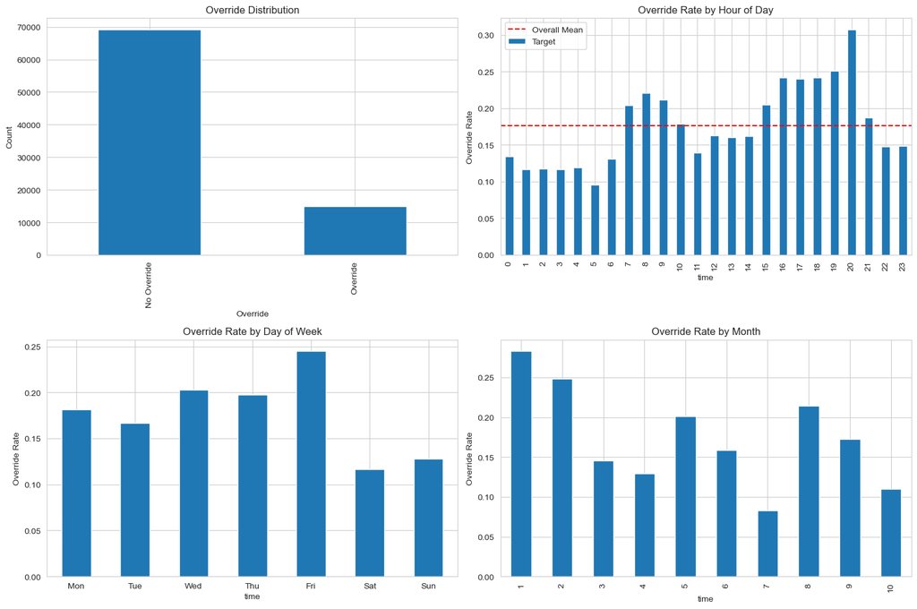

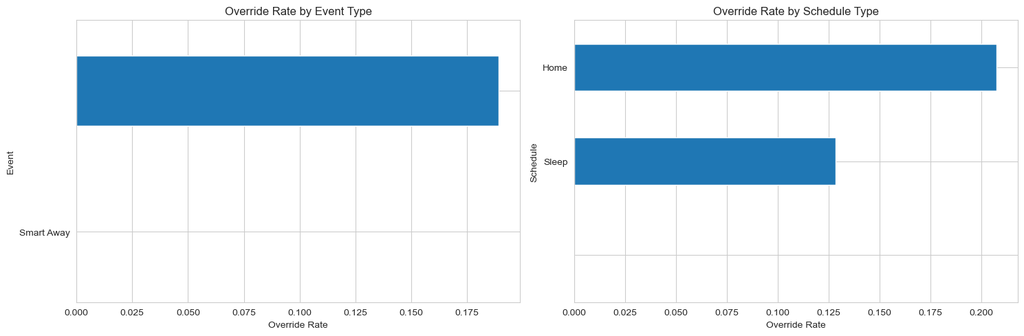

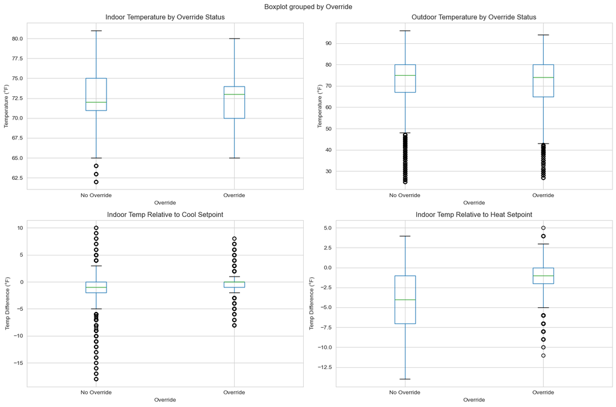

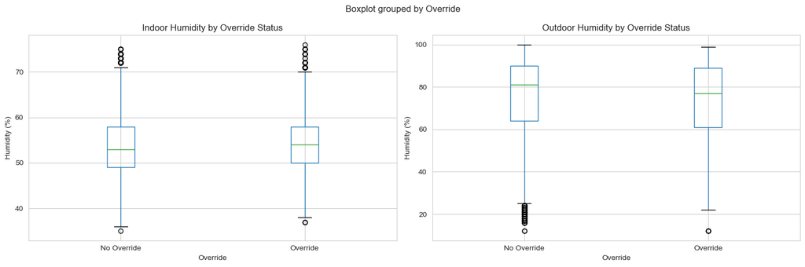

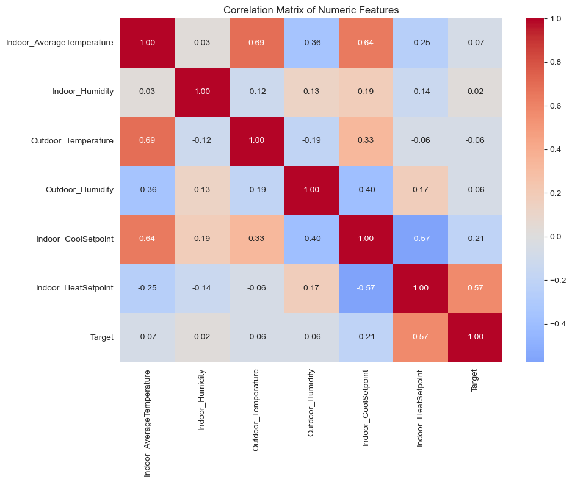

```
==================================================
SUMMARY STATISTICS BY OVERRIDE STATUS
==================================================

Numeric Features:
             Indoor_AverageTemperature  Indoor_Humidity  Outdoor_Temperature  \
Override
No Override                  72.817922        54.047780            73.029877
Override                     72.356143        54.395438            71.289059

             Outdoor_Humidity  Indoor_CoolSetpoint  Indoor_HeatSetpoint
Override
No Override         75.707261            74.277140            68.675759
Override            72.854663            72.697685            71.210335

==================================================
CATEGORICAL FEATURE DISTRIBUTIONS
==================================================

Event Distribution:
Event
              78554
Smart Away     5542
Name: count, dtype: int64

Schedule Distribution:
Schedule
Home     51659
Sleep    32201
           236
Name: count, dtype: int64

==================================================
OVERRIDE PATTERNS
==================================================

Override Rate by Event:
                mean  count
Event
            0.189195  78554
Smart Away  0.000000   5542

Override Rate by Schedule:
              mean  count
Schedule
Home      0.207708  51659
Sleep     0.128319  32201
          0.000000    236

==================================================
VERIFICATION: Train DataFrame unchanged
==================================================
Train shape: (84096, 10)
Train columns: ['Event', 'Schedule', 'Indoor_AverageTemperature', 'Indoor_Humidity', 'Outdoor_Temperature', 'Outdoor_Humidity', 'Indoor_CoolSetpoint', 'Indoor_HeatSetpoint', 'Override', 'Target']
```

```python
# Set style
sns.set_style("whitegrid")
plt.rcParams['figure.figsize'] = (15, 10)

# Create temporary features for analysis ONLY (don't modify train)
hour = train.index.hour
day_of_week = train.index.dayofweek
month = train.index.month
is_weekend = day_of_week.isin([5, 6]).astype(int)

# Temperature comfort metrics (temporary)
temp_above_cool = train['Indoor_AverageTemperature'] - train['Indoor_CoolSetpoint']
temp_below_heat = train['Indoor_HeatSetpoint'] - train['Indoor_AverageTemperature']

# ============================================================================
# 1. TARGET VARIABLE ANALYSIS
# ============================================================================

fig, axes = plt.subplots(2, 2, figsize=(15, 10))

# Override distribution
train['Override'].value_counts().plot(kind='bar', ax=axes[0,0])
axes[0,0].set_title('Override Distribution')
axes[0,0].set_ylabel('Count')

# Override by hour
override_by_hour = train.groupby(hour)['Target'].mean()
override_by_hour.plot(kind='bar', ax=axes[0,1])
axes[0,1].set_title('Override Rate by Hour of Day')
axes[0,1].set_ylabel('Override Rate')
axes[0,1].axhline(train['Target'].mean(), color='red', linestyle='--', label='Overall Mean')
axes[0,1].legend()

# Override by day of week
override_by_dow = train.groupby(day_of_week)['Target'].mean()
override_by_dow.plot(kind='bar', ax=axes[1,0])
axes[1,0].set_title('Override Rate by Day of Week')
axes[1,0].set_xticklabels(['Mon', 'Tue', 'Wed', 'Thu', 'Fri', 'Sat', 'Sun'], rotation=0)
axes[1,0].set_ylabel('Override Rate')

# Override by month
override_by_month = train.groupby(month)['Target'].mean()
override_by_month.plot(kind='bar', ax=axes[1,1])
axes[1,1].set_title('Override Rate by Month')
axes[1,1].set_ylabel('Override Rate')

plt.tight_layout()
plt.show()

# ============================================================================
# 2. CATEGORICAL FEATURES
# ============================================================================

fig, axes = plt.subplots(1, 2, figsize=(15, 5))

# Override by Event
override_by_event = train.groupby('Event')['Target'].mean().sort_values()
override_by_event.plot(kind='barh', ax=axes[0])
axes[0].set_title('Override Rate by Event Type')
axes[0].set_xlabel('Override Rate')

# Override by Schedule
override_by_schedule = train.groupby('Schedule')['Target'].mean().sort_values()
override_by_schedule.plot(kind='barh', ax=axes[1])
axes[1].set_title('Override Rate by Schedule Type')
axes[1].set_xlabel('Override Rate')

plt.tight_layout()
plt.show()

# ============================================================================
# 3. TEMPERATURE ANALYSIS
# ============================================================================

fig, axes = plt.subplots(2, 2, figsize=(15, 10))

# Indoor temp distribution by override
train.boxplot(column='Indoor_AverageTemperature', by='Override', ax=axes[0,0])
axes[0,0].set_title('Indoor Temperature by Override Status')
axes[0,0].set_xlabel('Override')
axes[0,0].set_ylabel('Temperature (°F)')
plt.sca(axes[0,0])
plt.xticks(rotation=0)

# Outdoor temp distribution by override
train.boxplot(column='Outdoor_Temperature', by='Override', ax=axes[0,1])
axes[0,1].set_title('Outdoor Temperature by Override Status')
axes[0,1].set_xlabel('Override')
axes[0,1].set_ylabel('Temperature (°F)')
plt.sca(axes[0,1])
plt.xticks(rotation=0)

# Temperature comfort zones (using temporary variables)
# Create temporary DataFrame for plotting
temp_comfort_df = pd.DataFrame({
    'Override': train['Override'],
    'temp_vs_cool': temp_above_cool,
    'temp_vs_heat': temp_below_heat
})

temp_comfort_df.boxplot(column='temp_vs_cool', by='Override', ax=axes[1,0])
axes[1,0].set_title('Indoor Temp Relative to Cool Setpoint')
axes[1,0].set_xlabel('Override')
axes[1,0].set_ylabel('Temp Difference (°F)')
plt.sca(axes[1,0])
plt.xticks(rotation=0)

temp_comfort_df.boxplot(column='temp_vs_heat', by='Override', ax=axes[1,1])
axes[1,1].set_title('Indoor Temp Relative to Heat Setpoint')
axes[1,1].set_xlabel('Override')
axes[1,1].set_ylabel('Temp Difference (°F)')
plt.sca(axes[1,1])
plt.xticks(rotation=0)

plt.tight_layout()
plt.show()

# ============================================================================
# 4. HUMIDITY ANALYSIS
# ============================================================================

fig, axes = plt.subplots(1, 2, figsize=(15, 5))

train.boxplot(column='Indoor_Humidity', by='Override', ax=axes[0])
axes[0].set_title('Indoor Humidity by Override Status')
axes[0].set_xlabel('Override')
axes[0].set_ylabel('Humidity (%)')
plt.sca(axes[0])
plt.xticks(rotation=0)

train.boxplot(column='Outdoor_Humidity', by='Override', ax=axes[1])
axes[1].set_title('Outdoor Humidity by Override Status')
axes[1].set_xlabel('Override')
axes[1].set_ylabel('Humidity (%)')
plt.sca(axes[1])
plt.xticks(rotation=0)

plt.tight_layout()
plt.show()

# ============================================================================
# 5. CORRELATION HEATMAP
# ============================================================================

numeric_cols = ['Indoor_AverageTemperature', 'Indoor_Humidity',
                'Outdoor_Temperature', 'Outdoor_Humidity',
                'Indoor_CoolSetpoint', 'Indoor_HeatSetpoint', 'Target']
corr_matrix = train[numeric_cols].corr()

plt.figure(figsize=(10, 8))
sns.heatmap(corr_matrix, annot=True, fmt='.2f', cmap='coolwarm', center=0)
plt.title('Correlation Matrix of Numeric Features')
plt.tight_layout()
plt.show()

# ============================================================================
# 6. SUMMARY STATISTICS
# ============================================================================

print("\n" + "="*50)
print("SUMMARY STATISTICS BY OVERRIDE STATUS")
print("="*50)
print("\nNumeric Features:")
print(train.groupby('Override')[numeric_cols[:-1]].mean())

print("\n" + "="*50)
print("CATEGORICAL FEATURE DISTRIBUTIONS")
print("="*50)
print("\nEvent Distribution:")
print(train['Event'].value_counts())
print("\nSchedule Distribution:")
print(train['Schedule'].value_counts())

print("\n" + "="*50)
print("OVERRIDE PATTERNS")
print("="*50)
print("\nOverride Rate by Event:")
print(train.groupby('Event')['Target'].agg(['mean', 'count']).sort_values('mean', ascending=False))
print("\nOverride Rate by Schedule:")
print(train.groupby('Schedule')['Target'].agg(['mean', 'count']).sort_values('mean', ascending=False))

# Verify train hasn't been modified
print("\n" + "="*50)
print("VERIFICATION: Train DataFrame unchanged")
print("="*50)
print(f"Train shape: {train.shape}")
print(f"Train columns: {list(train.columns)}")
```

### Feature Engineering

What features do you think will be most important in your model and why? These can be either provided or engineered features. Then, try to be creative in coming up with an expansive set of features to provide to your model. Finally, what features do you think would improve your model that you don't have access to currently and, if you had more time, how would you go about collecting that data?

```python
# ============================================================================
# STEP 1: Feature Engineering Function
# ============================================================================

def engineer_features(df, train_stats=None):
    """
    Apply all feature engineering transformations (excluding lag features).

    Parameters:
    - df: DataFrame to transform
    - train_stats: Dictionary of training statistics for test set transformations

    Returns:
    - Transformed DataFrame
    """
    df = df.copy()

    # 1. TEMPORAL FEATURES
    df['hour'] = df.index.hour
    df['day_of_week'] = df.index.dayofweek
    df['month'] = df.index.month
    df['day_of_year'] = df.index.dayofyear
    df['week_of_year'] = df.index.isocalendar().week
    df['is_weekend'] = df['day_of_week'].isin([5, 6]).astype(int)
    df['is_morning_peak'] = df['hour'].isin([7, 8, 9]).astype(int)
    df['is_evening_peak'] = df['hour'].isin([19, 20, 21]).astype(int)
    df['time_period'] = pd.cut(df['hour'], bins=[-1, 6, 12, 18, 24],
                                labels=['night', 'morning', 'afternoon', 'evening'])
    df['season'] = pd.cut(df['month'], bins=[0, 3, 6, 9, 12],
                          labels=['winter', 'spring', 'summer', 'fall'])

    # 2. TEMPERATURE COMFORT FEATURES
    df['temp_above_cool'] = df['Indoor_AverageTemperature'] - df['Indoor_CoolSetpoint']
    df['temp_below_heat'] = df['Indoor_HeatSetpoint'] - df['Indoor_AverageTemperature']
    df['deadband_width'] = df['Indoor_CoolSetpoint'] - df['Indoor_HeatSetpoint']
    df['in_deadband'] = ((df['Indoor_AverageTemperature'] >= df['Indoor_HeatSetpoint']) &
                         (df['Indoor_AverageTemperature'] <= df['Indoor_CoolSetpoint'])).astype(int)
    df['too_cold'] = (df['Indoor_AverageTemperature'] < df['Indoor_HeatSetpoint']).astype(int)
    df['too_hot'] = (df['Indoor_AverageTemperature'] > df['Indoor_CoolSetpoint']).astype(int)
    df['setpoint_midpoint'] = (df['Indoor_CoolSetpoint'] + df['Indoor_HeatSetpoint']) / 2
    df['temp_from_ideal'] = abs(df['Indoor_AverageTemperature'] - df['setpoint_midpoint'])

    # 3. WEATHER AND ENVIRONMENTAL FEATURES
    df['temp_differential'] = df['Indoor_AverageTemperature'] - df['Outdoor_Temperature']
    df['humidity_differential'] = df['Indoor_Humidity'] - df['Outdoor_Humidity']
    df['outdoor_temp_change_1h'] = df['Outdoor_Temperature'].diff(12)
    df['indoor_temp_change_1h'] = df['Indoor_AverageTemperature'].diff(12)
    df['rapid_outdoor_change'] = (abs(df['outdoor_temp_change_1h']) > 5).astype(int)

    # Use training stats for extreme weather thresholds if provided
    if train_stats is not None:
        df['extreme_cold'] = (df['Outdoor_Temperature'] < train_stats['outdoor_temp_q10']).astype(int)
        df['extreme_heat'] = (df['Outdoor_Temperature'] > train_stats['outdoor_temp_q90']).astype(int)
        df['extreme_outdoor_humidity'] = (df['Outdoor_Humidity'] > train_stats['outdoor_humidity_q90']).astype(int)
    else:
        df['extreme_cold'] = (df['Outdoor_Temperature'] < df['Outdoor_Temperature'].quantile(0.1)).astype(int)
        df['extreme_heat'] = (df['Outdoor_Temperature'] > df['Outdoor_Temperature'].quantile(0.9)).astype(int)
        df['extreme_outdoor_humidity'] = (df['Outdoor_Humidity'] > df['Outdoor_Humidity'].quantile(0.9)).astype(int)

    # 4. BEHAVIORAL AND INTERACTION FEATURES
    df['schedule_changed'] = (df['Schedule'] != df['Schedule'].shift(1)).astype(int)
    df['event_changed'] = (df['Event'] != df['Event'].shift(1)).astype(int)
    df['cool_setpoint_changed'] = (df['Indoor_CoolSetpoint'] != df['Indoor_CoolSetpoint'].shift(1)).astype(int)
    df['heat_setpoint_changed'] = (df['Indoor_HeatSetpoint'] != df['Indoor_HeatSetpoint'].shift(1)).astype(int)
    df['hour_weekend_interaction'] = df['hour'] * df['is_weekend']
    df['temp_season_interaction'] = df['Indoor_AverageTemperature'] * df['month']
    df['extreme_weather_peak'] = df['extreme_cold'] * df['is_evening_peak']

    # 5. MOVING AVERAGES (environmental trends)
    df['outdoor_temp_ma_1h'] = df['Outdoor_Temperature'].rolling(window=12, min_periods=1).mean()
    df['indoor_temp_ma_1h'] = df['Indoor_AverageTemperature'].rolling(window=12, min_periods=1).mean()

    return df

# ============================================================================
# STEP 2: Apply Feature Engineering
# ============================================================================

# Calculate training statistics for test set
train_stats = {
    'outdoor_temp_q10': train['Outdoor_Temperature'].quantile(0.1),
    'outdoor_temp_q90': train['Outdoor_Temperature'].quantile(0.9),
    'outdoor_humidity_q90': train['Outdoor_Humidity'].quantile(0.9)
}

# Apply to both sets
train = engineer_features(train, train_stats=None)  # Train uses its own stats
test = engineer_features(test, train_stats=train_stats)  # Test uses train stats

# ============================================================================
# STEP 3: Verify Consistency
# ============================================================================

print(f"Training set shape: {train.shape}")
print(f"Test set shape: {test.shape}")

# Check feature alignment (excluding Target and Override)
train_features = sorted([col for col in train.columns if col not in ['Target', 'Override']])
test_features = sorted([col for col in test.columns if col not in ['Target', 'Override']])

print(f"\nTrain features (excluding Target): {len(train_features)}")
print(f"Test features (excluding Target): {len(test_features)}")

if train_features == test_features:
    print("✓ Feature sets match perfectly!")
else:
    train_set = set(train_features)
    test_set = set(test_features)
    print(f"\n✗ Mismatch detected:")
    if train_set - test_set:
        print(f"  In train but not test: {train_set - test_set}")
    if test_set - train_set:
        print(f"  In test but not train: {test_set - train_set}")

# Summary
original_features = ['Event', 'Schedule', 'Indoor_AverageTemperature', 'Indoor_Humidity',
                     'Outdoor_Temperature', 'Outdoor_Humidity', 'Indoor_CoolSetpoint',
                     'Indoor_HeatSetpoint']
engineered_count = len(train_features) - len(original_features)

print(f"\n" + "="*50)
print(f"FEATURE ENGINEERING SUMMARY")
print(f"="*50)
print(f"Original features: {len(original_features)}")
print(f"Engineered features: {engineered_count}")
print(f"Total features: {len(train_features)}")
print(f"Train observations: {len(train):,}")
print(f"Test observations: {len(test):,}")
print(f"Train override rate: {train['Target'].mean():.2%}")
print(f"Test override rate: {test['Target'].mean():.2%}")
```

```
Training set shape: (84096, 45)
Test set shape: (21024, 45)

Train features (excluding Target): 43
Test features (excluding Target): 43
✓ Feature sets match perfectly!

==================================================
FEATURE ENGINEERING SUMMARY
==================================================
Original features: 8
Engineered features: 35
Total features: 43
Train observations: 84,096
Test observations: 21,024
Train override rate: 17.67%
Test override rate: 13.04%
```

### Modeling

#### First Model - Selection and Fitting

Deliberately limit the complexity of your first model using model or feature selection. The goal is to see how much you can get done with a simple model, and not necessarily to create something that performs poorly. Use cross validation if your model has hyperparameters.

```python
# ============================================================================
# FIRST MODEL: FEATURE SELECTION AND MULTICOLLINEARITY CHECK
# ============================================================================

print("="*60)
print("FIRST MODEL: FEATURE SELECTION")
print("="*60)

# ============================================================================
# STEP 1: PROPOSE FEATURES - Based on EDA Findings
# ============================================================================

print("\n" + "="*60)
print("STEP 1: PROPOSE FEATURE CANDIDATES")
print("="*60)

print("\nStrategy: Deliberately limit complexity by selecting features with")
print("strongest signals from EDA (temporal patterns, categorical separators,")
print("and numeric features with meaningful correlations to TARGET)")

print("\n" + "-"*60)
print("REVIEW: Correlation with Target from EDA")
print("-"*60)
print("  Indoor_HeatSetpoint:         0.57  (Strong - INCLUDE)")
print("  Indoor_CoolSetpoint:        -0.21  (Moderate - INCLUDE)")
print("  Indoor_AverageTemperature:  -0.07  (Weak - EXCLUDE)")
print("  Outdoor_Temperature:        -0.06  (Weak - EXCLUDE)")
print("  Indoor_Humidity:             0.02  (Negligible - EXCLUDE)")
print("  Outdoor_Humidity:           -0.06  (Weak - EXCLUDE)")

# Select limited feature set
selected_features = [
    # Temporal features (strongest signals from EDA)
    'hour',              # Override rate: 9% (3AM) to 31% (8PM)
    'is_weekend',        # Friday 25% vs Saturday 12%
    'month',             # January 28% vs July 8%

    # Categorical features (perfect separator + strong signal)
    'Event',             # Smart Away = 0% override (perfect separator)
    'Schedule',          # Home 21% vs Sleep 13%

    # Temperature features (only meaningful correlations |r| > 0.20)
    'Indoor_HeatSetpoint',    # r = 0.57 (strongest numeric predictor)
    'Indoor_CoolSetpoint',    # r = -0.21 (moderate signal)
]

print("\n" + "-"*60)
print(f"PROPOSED FEATURE SET: {len(selected_features)} features")
print("-"*60)

for i, feat in enumerate(selected_features, 1):
    print(f"  {i}. {feat}")

print("\nRationale for each feature:")
print("  • hour: Strong temporal pattern (override rate varies 9% to 31%)")
print("  • is_weekend: Weekend behavior differs (Fri 25% vs Sat 12%)")
print("  • month: Seasonal variation (winter 28% vs summer 8%)")
print("  • Event: Perfect separator (Smart Away has 0% override rate)")
print("  • Schedule: Schedule type matters (Home 21% vs Sleep 13%)")
print("  • Indoor_HeatSetpoint: Strongest correlation with target (r=0.57)")
print("  • Indoor_CoolSetpoint: Moderate correlation with target (r=-0.21)")

print("\nFeatures deliberately EXCLUDED:")
print("  • Indoor_AverageTemperature: Weak correlation with target (r=-0.07)")
print("  • Outdoor_Temperature: Weak correlation with target (r=-0.06)")
print("  • Humidity features: Negligible correlations with target (|r| < 0.06)")
print("  • All 35 engineered features: Starting with simple baseline")

# Create candidate feature matrices
X_train_candidate = train[selected_features].copy()
X_test_candidate = test[selected_features].copy()
y_train = train['Target']
y_test = test['Target']

print(f"\nCandidate feature matrix shapes:")
print(f"  X_train: {X_train_candidate.shape}")
print(f"  X_test: {X_test_candidate.shape}")

# ============================================================================
# STEP 2: CHECK MULTICOLLINEARITY
# ============================================================================

print("\n" + "="*60)
print("STEP 2: MULTICOLLINEARITY CHECK")
print("="*60)
print("Purpose: Verify selected features are not too correlated WITH EACH OTHER")
print("Note: We already checked correlation WITH TARGET in Step 1")

# Separate numeric features for multicollinearity analysis
numeric_features = [
    'hour',
    'is_weekend',
    'month',
    'Indoor_HeatSetpoint',
    'Indoor_CoolSetpoint',
]

print(f"\nAnalyzing {len(numeric_features)} numeric features...")
print("(Categorical features Event and Schedule will be encoded later)")

# --- Correlation Matrix ---
print("\n" + "-"*60)
print("CORRELATION MATRIX (Between Features)")
print("-"*60)

correlation_matrix = X_train_candidate[numeric_features].corr()
print(correlation_matrix.round(3))

# Visualize correlation matrix
plt.figure(figsize=(9, 7))
sns.heatmap(correlation_matrix, annot=True, fmt='.2f', cmap='coolwarm',
            center=0, square=True, linewidths=1, cbar_kws={'label': 'Correlation'})
plt.title('Correlation Matrix - Features vs Features\n(Not with Target)',
          fontsize=14, fontweight='bold')
plt.tight_layout()
plt.show()

# --- Identify High Correlations ---
print("\n" + "-"*60)
print("HIGH CORRELATIONS BETWEEN FEATURES (|r| > 0.5)")
print("-"*60)
print("This checks if features are correlated WITH EACH OTHER")

high_corr_pairs = []
for i in range(len(correlation_matrix.columns)):
    for j in range(i+1, len(correlation_matrix.columns)):
        corr_val = correlation_matrix.iloc[i, j]
        if abs(corr_val) > 0.5:
            high_corr_pairs.append({
                'Feature 1': correlation_matrix.columns[i],
                'Feature 2': correlation_matrix.columns[j],
                'Correlation': corr_val
            })

if high_corr_pairs:
    high_corr_df = pd.DataFrame(high_corr_pairs)
    print(high_corr_df.to_string(index=False))
    print("\n⚠️  These feature pairs are correlated WITH EACH OTHER")
    print("This creates multicollinearity (features carry redundant information)")
else:
    print("✓ No feature pairs with |correlation| > 0.5")

# --- Variance Inflation Factor (VIF) ---
print("\n" + "-"*60)
print("VARIANCE INFLATION FACTOR (VIF)")
print("-"*60)
print("VIF measures how well each feature can be predicted FROM OTHER FEATURES")
print("(not from the target)\n")
print("Interpretation:")
print("  VIF < 5:      Low multicollinearity (acceptable)")
print("  5 ≤ VIF < 10: Moderate multicollinearity (caution)")
print("  VIF ≥ 10:     High multicollinearity (problematic)")
print()
```

```python
# Calculate VIF
vif_data = pd.DataFrame()
vif_data['Feature'] = numeric_features
vif_data['VIF'] = [variance_inflation_factor(X_train_candidate[numeric_features].values, i)
                   for i in range(len(numeric_features))]
vif_data = vif_data.sort_values('VIF', ascending=False)

print(vif_data.to_string(index=False))

# Categorize VIF levels
high_vif = vif_data[vif_data['VIF'] >= 10]
moderate_vif = vif_data[(vif_data['VIF'] >= 5) & (vif_data['VIF'] < 10)]
low_vif = vif_data[vif_data['VIF'] < 5]

# Visualize VIF
fig, ax = plt.subplots(figsize=(10, 6))
colors = ['red' if x >= 10 else 'orange' if x >= 5 else 'green'
          for x in vif_data['VIF']]
ax.barh(vif_data['Feature'], vif_data['VIF'], color=colors)
ax.axvline(x=5, color='orange', linestyle='--', linewidth=1.5, label='VIF = 5 (Caution)', alpha=0.7)
ax.axvline(x=10, color='red', linestyle='--', linewidth=1.5, label='VIF = 10 (High Risk)', alpha=0.7)
ax.set_xlabel('VIF Value', fontsize=11)
ax.set_title('Variance Inflation Factor by Feature\n(Measures correlation WITH OTHER FEATURES)',
             fontsize=13, fontweight='bold')
ax.legend(fontsize=10)
ax.grid(axis='x', alpha=0.3)
plt.tight_layout()
plt.show()

print("\n" + "-"*60)
print("VIF SUMMARY")
print("-"*60)

if len(high_vif) > 0:
    print(f"⚠️  HIGH VIF (≥10): {len(high_vif)} features")
    for _, row in high_vif.iterrows():
        print(f"    - {row['Feature']}: VIF = {row['VIF']:.2f}")
else:
    print("✓ No features with HIGH VIF (≥10)")

if len(moderate_vif) > 0:
    print(f"⚠️  MODERATE VIF (5-10): {len(moderate_vif)} features")
    for _, row in moderate_vif.iterrows():
        print(f"    - {row['Feature']}: VIF = {row['VIF']:.2f}")
else:
    print("✓ No features with MODERATE VIF (5-10)")

print(f"✓ LOW VIF (<5): {len(low_vif)} features")

# ============================================================================
# STEP 3: DECISION - WHICH FEATURES TO USE
# ============================================================================

print("\n" + "="*60)
print("STEP 3: FINAL FEATURE SELECTION DECISION")
print("="*60)

if len(high_vif) > 0:
    print("\n⚠️  MULTICOLLINEARITY DETECTED")
    print("\nFeatures with VIF ≥ 10 (correlated WITH EACH OTHER):")
    for _, row in high_vif.iterrows():
        print(f"  - {row['Feature']}: VIF = {row['VIF']:.2f}")

    # Check if setpoints are the problem
    setpoint_vif = high_vif[high_vif['Feature'].str.contains('Setpoint')]

    if len(setpoint_vif) > 1:
        print("\n" + "-"*60)
        print("ISSUE IDENTIFIED: Both Setpoints have high VIF")
        print("-"*60)
        print("\nExplanation:")
        print("  • Indoor_HeatSetpoint and Indoor_CoolSetpoint are correlated WITH EACH OTHER")
        print("  • Correlation between them: r = -0.575 (they define deadband)")
        print("  • When one is high, the other tends to be high too (maintaining gap)")
        print("  • This creates multicollinearity - can't include both in linear model")

        print("\n" + "-"*60)
        print("DECISION CRITERION")
        print("-"*60)
        print("Since both setpoints are correlated WITH EACH OTHER,")
        print("we must choose ONE based on correlation WITH TARGET:")

        print("\nCorrelation WITH TARGET (from EDA):")
        print("  • Indoor_HeatSetpoint → Target:  r = 0.57  (Strong)")
        print("  • Indoor_CoolSetpoint → Target:  r = -0.21 (Moderate)")

        print("\n" + "-"*60)
        print("DECISION: Keep Indoor_HeatSetpoint, Remove Indoor_CoolSetpoint")
        print("-"*60)
        print("\nRATIONALE:")
        print("  1. Both setpoints have VIF > 300 (extreme multicollinearity WITH EACH OTHER)")
        print("  2. Must choose only ONE to avoid unstable coefficients")
        print("  3. HeatSetpoint has MUCH stronger correlation WITH TARGET (0.57 vs -0.21)")
        print("  4. Keeping HeatSetpoint preserves our strongest numeric predictor")
        print("  5. CoolSetpoint adds little additional predictive power given HeatSetpoint")

        features_to_remove = ['Indoor_CoolSetpoint']
        final_features = [f for f in selected_features if f not in features_to_remove]

        # Recalculate VIF after removal
        print("\n" + "-"*60)
        print("VIF AFTER REMOVING Indoor_CoolSetpoint")
        print("-"*60)

        numeric_features_reduced = [f for f in numeric_features if f not in features_to_remove]
        X_train_reduced = X_train_candidate[numeric_features_reduced]

        vif_data_new = pd.DataFrame()
        vif_data_new['Feature'] = numeric_features_reduced
        vif_data_new['VIF'] = [variance_inflation_factor(X_train_reduced.values, i)
                               for i in range(len(numeric_features_reduced))]
        vif_data_new = vif_data_new.sort_values('VIF', ascending=False)

        print(vif_data_new.to_string(index=False))

        high_vif_new = vif_data_new[vif_data_new['VIF'] >= 10]
        if len(high_vif_new) == 0:
            print("\n✓ SUCCESS: All features now have VIF < 10")
            print("Multicollinearity resolved!")
        else:
            print(f"\n⚠️  Still {len(high_vif_new)} features with VIF ≥ 10")

    else:
        # Other high VIF features (not setpoints)
        print("\nDECISION: Use regularization to manage multicollinearity")
        print("\nRATIONALE:")
        print("  - Logistic Regression with L2 penalty can handle moderate multicollinearity")
        print("  - Cross-validation will optimize regularization strength")
        final_features = selected_features

elif len(moderate_vif) > 0:
    print("\n⚠️  MODERATE MULTICOLLINEARITY DETECTED")
    print("\nFeatures with 5 ≤ VIF < 10:")
    for _, row in moderate_vif.iterrows():
        print(f"  - {row['Feature']}: VIF = {row['VIF']:.2f}")

    print("\n" + "-"*60)
    print("DECISION: Keep all features")
    print("-"*60)
    print("\nRATIONALE:")
    print("  - Moderate VIF (5-10) is acceptable for regularized models")
    print("  - Logistic Regression with L2 penalty handles this well")
    print("  - Cross-validation will optimize regularization strength")
```

```
============================================================
FIRST MODEL: FEATURE SELECTION
============================================================

============================================================
STEP 1: PROPOSE FEATURE CANDIDATES
============================================================

Strategy: Deliberately limit complexity by selecting features with
strongest signals from EDA (temporal patterns, categorical separators,
and numeric features with meaningful correlations to TARGET)

------------------------------------------------------------
REVIEW: Correlation with Target from EDA
------------------------------------------------------------
  Indoor_HeatSetpoint:         0.57  (Strong - INCLUDE)
  Indoor_CoolSetpoint:        -0.21  (Moderate - INCLUDE)
  Indoor_AverageTemperature:  -0.07  (Weak - EXCLUDE)
  Outdoor_Temperature:        -0.06  (Weak - EXCLUDE)
  Indoor_Humidity:             0.02  (Negligible - EXCLUDE)
  Outdoor_Humidity:           -0.06  (Weak - EXCLUDE)

------------------------------------------------------------
PROPOSED FEATURE SET: 7 features
------------------------------------------------------------
  1. hour
  2. is_weekend
  3. month
  4. Event
  5. Schedule
  6. Indoor_HeatSetpoint
  7. Indoor_CoolSetpoint

Rationale for each feature:
  • hour: Strong temporal pattern (override rate varies 9% to 31%)
  • is_weekend: Weekend behavior differs (Fri 25% vs Sat 12%)
  • month: Seasonal variation (winter 28% vs summer 8%)
  • Event: Perfect separator (Smart Away has 0% override rate)
  • Schedule: Schedule type matters (Home 21% vs Sleep 13%)
  • Indoor_HeatSetpoint: Strongest correlation with target (r=0.57)
```

[output cut: 22 more lines]

```
CORRELATION MATRIX (Between Features)
------------------------------------------------------------
                      hour  is_weekend  month  Indoor_HeatSetpoint  \
hour                 1.000      -0.000  0.000               -0.094
is_weekend          -0.000       1.000 -0.004               -0.101
month                0.000      -0.004  1.000                0.080
Indoor_HeatSetpoint -0.094      -0.101  0.080                1.000
Indoor_CoolSetpoint  0.290       0.082  0.053               -0.575

                     Indoor_CoolSetpoint
hour                               0.290
is_weekend                         0.082
month                              0.053
Indoor_HeatSetpoint               -0.575
Indoor_CoolSetpoint                1.000
```

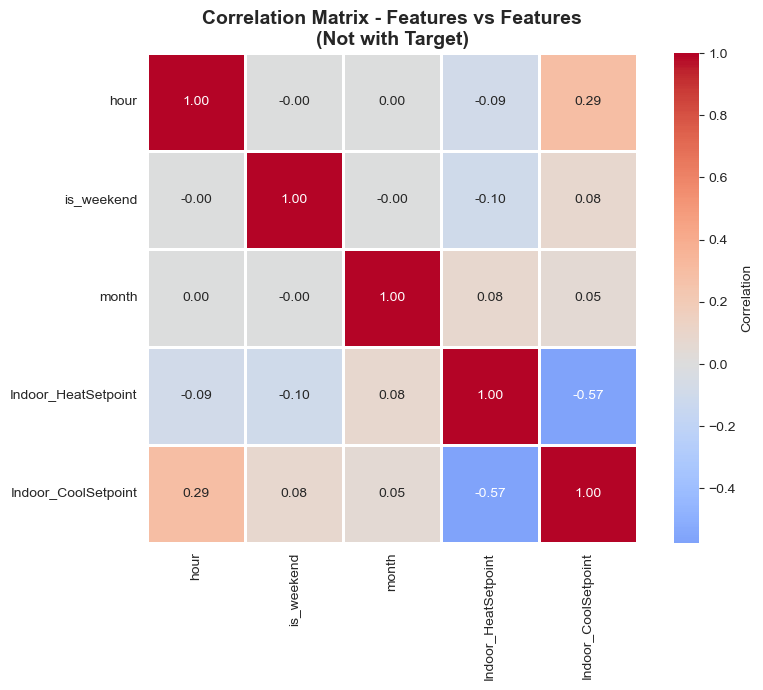

```
------------------------------------------------------------
HIGH CORRELATIONS BETWEEN FEATURES (|r| > 0.5)
------------------------------------------------------------
This checks if features are correlated WITH EACH OTHER
          Feature 1           Feature 2  Correlation
Indoor_HeatSetpoint Indoor_CoolSetpoint    -0.574856

⚠️  These feature pairs are correlated WITH EACH OTHER
This creates multicollinearity (features carry redundant information)

------------------------------------------------------------
VARIANCE INFLATION FACTOR (VIF)
------------------------------------------------------------
VIF measures how well each feature can be predicted FROM OTHER FEATURES
(not from the target)

Interpretation:
  VIF < 5:      Low multicollinearity (acceptable)
  5 ≤ VIF < 10: Moderate multicollinearity (caution)
  VIF ≥ 10:     High multicollinearity (problematic)

            Feature        VIF
Indoor_CoolSetpoint 341.742769
Indoor_HeatSetpoint 325.831580
              month   4.727902
               hour   4.028222
         is_weekend   1.411177
```

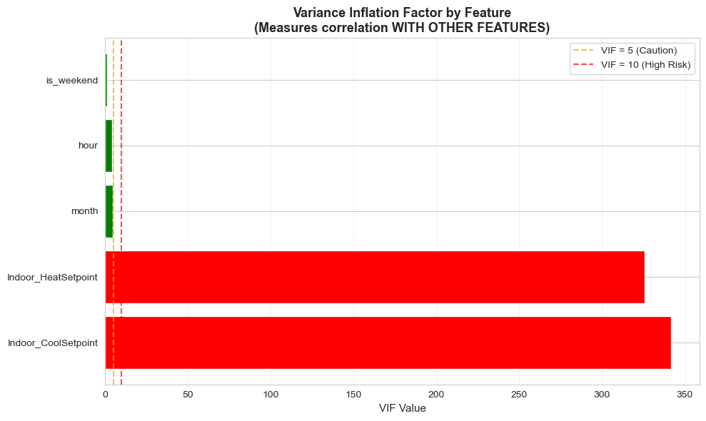

[output not shown]

[output cut: 36 more lines]

[output not shown]

```python
    final_features = selected_features

else:
    print("\n✓ NO MULTICOLLINEARITY CONCERNS")
    print("\nAll features have VIF < 5 (low multicollinearity)")

    print("\n" + "-"*60)
    print("DECISION: Keep all features")
    print("-"*60)
    print("\nRATIONALE:")
    print("  - No problematic correlations between features")
    print("  - All features provide independent information")
    print("  - Feature selection based on correlation WITH TARGET was successful")

    final_features = selected_features

# ============================================================================
# FINAL FEATURE SET
# ============================================================================

print("\n" + "="*60)
print("FINAL FEATURE SET FOR MODELING")
print("="*60)

print(f"\nTotal features: {len(final_features)}")
print("\nFeatures to be used in model:")

# Get final VIF values for numeric features
if len([f for f in final_features if f in numeric_features or f in ['Indoor_HeatSetpoint']]) > 0:
    numeric_final = [f for f in final_features if f in numeric_features or f == 'Indoor_HeatSetpoint']
    X_final_numeric = train[numeric_final]

    if len(numeric_final) > 1:
        vif_final = pd.DataFrame()
        vif_final['Feature'] = numeric_final
        vif_final['VIF'] = [variance_inflation_factor(X_final_numeric.values, i)
                           for i in range(len(numeric_final))]

for i, feat in enumerate(final_features, 1):
    if feat in numeric_features or feat == 'Indoor_HeatSetpoint':
        try:
            vif_val = vif_final[vif_final['Feature'] == feat]['VIF'].values[0]
            print(f"  {i}. {feat:25s} (VIF: {vif_val:.2f})")
        except:
            print(f"  {i}. {feat:25s} (Numeric)")
    else:
        print(f"  {i}. {feat:25s} (Categorical - will be encoded)")

print("\n" + "="*60)
print("FEATURE SELECTION COMPLETE")
print("="*60)
print("\nKey outcomes:")
print(f"  • Started with {len(selected_features)} proposed features")
print(f"  • Removed {len(selected_features) - len(final_features)} feature(s) due to multicollinearity")
print(f"  • Final model uses {len(final_features)} features")
print(f"  • Selection based on: (1) correlation WITH TARGET, (2) low VIF (independence FROM other features)")

print("\nNext steps:")
print("  1. Encode categorical features (Event, Schedule)")
print("  2. Scale numeric features")
print("  3. Train Logistic Regression with cross-validation")
print("  4. Evaluate model performance")

# Store for next step
final_features_list = final_features.copy()
```

```python
# ============================================================================
# FIRST MODEL: MODEL FITTING
# ============================================================================

print("="*60)
print("FIRST MODEL: FITTING")
print("="*60)

# ============================================================================
# STEP 1: PREPARE DATA FOR MODELING
# ============================================================================

print("\n" + "="*60)
print("STEP 1: DATA PREPARATION")
print("="*60)

# Use final features from previous step
X_train_simple = train[final_features_list].copy()
X_test_simple = test[final_features_list].copy()

print(f"\nSelected features: {final_features_list}")
print(f"\nX_train shape: {X_train_simple.shape}")
print(f"X_test shape: {X_test_simple.shape}")

# ============================================================================
# STEP 2: ENCODE CATEGORICAL FEATURES
# ============================================================================

print("\n" + "="*60)
print("STEP 2: ENCODE CATEGORICAL FEATURES")
print("="*60)

print("\nCategorical features to encode: Event, Schedule")
print("Method: One-hot encoding with drop_first=True")

# One-hot encode categorical variables
X_train_encoded = pd.get_dummies(X_train_simple, columns=['Event', 'Schedule'],
                                  drop_first=True)
X_test_encoded = pd.get_dummies(X_test_simple, columns=['Event', 'Schedule'],
                                 drop_first=True)

# Ensure train and test have same columns
train_cols = X_train_encoded.columns
for col in train_cols:
    if col not in X_test_encoded.columns:
        X_test_encoded[col] = 0
X_test_encoded = X_test_encoded[train_cols]

print(f"\nAfter encoding:")
print(f"  X_train shape: {X_train_encoded.shape}")
print(f"  X_test shape: {X_test_encoded.shape}")
print(f"  Total features: {X_train_encoded.shape[1]}")

print("\nEncoded feature names:")
for i, col in enumerate(X_train_encoded.columns, 1):
    print(f"  {i}. {col}")

# ============================================================================
# STEP 3: SCALE FEATURES
# ============================================================================

print("\n" + "="*60)
print("STEP 3: FEATURE SCALING")
print("="*60)

print("\nScaling method: StandardScaler")
print("Why: Logistic Regression is sensitive to feature scales")
print("     Regularization (L2 penalty) requires scaled features")

scaler = StandardScaler()
X_train_scaled = scaler.fit_transform(X_train_encoded)
X_test_scaled = scaler.transform(X_test_encoded)

print("\n✓ Features scaled (mean=0, std=1 for each feature)")

# ============================================================================
# STEP 4: HYPERPARAMETER TUNING WITH CROSS-VALIDATION
# ============================================================================

print("\n" + "="*60)
print("STEP 4: HYPERPARAMETER TUNING (5-FOLD CV)")
print("="*60)

print("\nModel: Logistic Regression")
print("Hyperparameter: C (inverse regularization strength)")
print("  - Lower C = Stronger regularization (simpler model)")
print("  - Higher C = Weaker regularization (more complex model)")

print("\nClass weights: Balanced")
print("  - Handles class imbalance (17.67% override vs 82.33% no override)")
print("  - Penalizes misclassifying minority class more heavily")

print("\nMetric: ROC-AUC (Area Under ROC Curve)")
print("  - Measures ability to distinguish between classes")
print("  - Range: 0.5 (random) to 1.0 (perfect)")
print()

C_values = [0.001, 0.01, 0.1, 1, 10, 100]
cv_scores = {}

print("-"*60)
print("Testing different C values:")
print("-"*60)

for C in C_values:
    model = LogisticRegression(C=C, max_iter=1000, random_state=42,
                               class_weight='balanced', solver='lbfgs')

    # 5-fold cross-validation
    scores = cross_val_score(model, X_train_scaled, y_train,
                            cv=5, scoring='roc_auc')

    cv_scores[C] = {
        'mean': scores.mean(),
        'std': scores.std(),
        'scores': scores
    }

    print(f"C = {C:7.3f} | Mean ROC-AUC: {scores.mean():.4f} (±{scores.std():.4f})")

# Select best C
best_C = max(cv_scores, key=lambda x: cv_scores[x]['mean'])
best_score = cv_scores[best_C]['mean']

print("\n" + "-"*60)
print(f"✓ Best C value: {best_C}")
print(f"  Cross-validation ROC-AUC: {best_score:.4f}")
print("-"*60)

# ============================================================================
# STEP 5: TRAIN FINAL MODEL
# ============================================================================

print("\n" + "="*60)
print("STEP 5: TRAIN FINAL MODEL")
print("="*60)

final_model = LogisticRegression(C=best_C, max_iter=1000, random_state=42,
                                 class_weight='balanced', solver='lbfgs')
final_model.fit(X_train_scaled, y_train)

print("\nModel Configuration:")
print(f"  Algorithm:        Logistic Regression")
print(f"  Regularization:   L2 (Ridge penalty)")
print(f"  C parameter:      {best_C}")
print(f"  Class weights:    Balanced")
print(f"  Solver:           lbfgs")
print(f"  Max iterations:   1000")
print(f"  Random state:     42")

print("\nTraining Data:")
print(f"  Input features:   {len(final_features_list)} original")
print(f"  Encoded features: {X_train_encoded.shape[1]}")
print(f"  Training samples: {len(X_train_scaled):,}")
print(f"  Positive class:   {y_train.sum():,} ({y_train.mean():.2%})")
print(f"  Negative class:   {(~y_train.astype(bool)).sum():,} ({(1-y_train.mean()):.2%})")

print("\n✓ Model training complete")

# ============================================================================
# STEP 6: GENERATE PREDICTIONS
# ============================================================================

print("\n" + "="*60)
print("STEP 6: GENERATE PREDICTIONS")
print("="*60)

# Predictions
y_train_pred = final_model.predict(X_train_scaled)
y_test_pred = final_model.predict(X_test_scaled)

# Predicted probabilities (for ROC curve)
y_train_proba = final_model.predict_proba(X_train_scaled)[:, 1]
y_test_proba = final_model.predict_proba(X_test_scaled)[:, 1]

print("\nPredictions generated:")
print(f"  Training set: {len(y_train_pred):,} predictions")
print(f"  Test set:     {len(y_test_pred):,} predictions")

print("\nPredicted class distribution (Test set):")
unique, counts = np.unique(y_test_pred, return_counts=True)
for cls, count in zip(unique, counts):
    print(f"  Class {cls}: {count:,} ({count/len(y_test_pred):.2%})")

# ============================================================================
# MODEL SUMMARY
# ============================================================================

print("\n" + "="*60)
print("FIRST MODEL: FITTING COMPLETE")
print("="*60)

print("\nModel Summary:")
print(f"  Type:              Logistic Regression (Simple Baseline)")
print(f"  Features:          {len(final_features_list)} original → {X_train_encoded.shape[1]} encoded")
print(f"  Best C (CV):       {best_C}")
print(f"  CV ROC-AUC:        {best_score:.4f}")
print(f"  Training samples:  {len(X_train_scaled):,}")
print(f"  Test samples:      {len(X_test_scaled):,}")

print("\nFeature List:")
for feat in final_features_list:
    print(f"  • {feat}")

print("\n" + "="*60)
print("Ready for evaluation...")
print("="*60)

# Store artifacts for evaluation
model_artifacts = {
    'model': final_model,
    'scaler': scaler,
    'X_train_scaled': X_train_scaled,
    'X_test_scaled': X_test_scaled,
    'X_train_encoded': X_train_encoded,
    'X_test_encoded': X_test_encoded,
    'y_train_pred': y_train_pred,
    'y_test_pred': y_test_pred,
    'y_train_proba': y_train_proba,
    'y_test_proba': y_test_proba,
    'feature_names': train_cols,
    'best_C': best_C,
    'cv_score': best_score
}
```

```
============================================================
FIRST MODEL: FITTING
============================================================

============================================================
STEP 1: DATA PREPARATION
============================================================

Selected features: ['hour', 'is_weekend', 'month', 'Event', 'Schedule', 'Indoor_HeatSetpoint']

X_train shape: (84096, 6)
X_test shape: (21024, 6)

============================================================
STEP 2: ENCODE CATEGORICAL FEATURES
============================================================

Categorical features to encode: Event, Schedule
Method: One-hot encoding with drop_first=True

After encoding:
  X_train shape: (84096, 7)
  X_test shape: (21024, 7)
  Total features: 7

Encoded feature names:
  1. hour
  2. is_weekend
  3. month
  4. Indoor_HeatSetpoint
  5. Event_Smart Away
  6. Schedule_Home
  7. Schedule_Sleep

============================================================
STEP 3: FEATURE SCALING
============================================================

Scaling method: StandardScaler
Why: Logistic Regression is sensitive to feature scales
```

[output cut: 78 more lines]

```
  CV ROC-AUC:        0.8541
  Training samples:  84,096
  Test samples:      21,024

Feature List:
  • hour
  • is_weekend
  • month
  • Event
  • Schedule
  • Indoor_HeatSetpoint

============================================================
Ready for evaluation...
============================================================
```

#### First Model - Evaluation

Create an in-sample and out-of-sample ROC curve and calculate the AUC for each.

```
============================================================
FIRST MODEL: EVALUATION
============================================================

============================================================
ROC CURVES AND AUC SCORES
============================================================

Area Under the Curve (AUC) Scores:
  IN-SAMPLE (Training):     0.8522
  OUT-OF-SAMPLE (Test):     0.6945
  Difference (Train - Test): 0.1577

⚠️  Potential overfitting (difference ≥ 0.10)
```

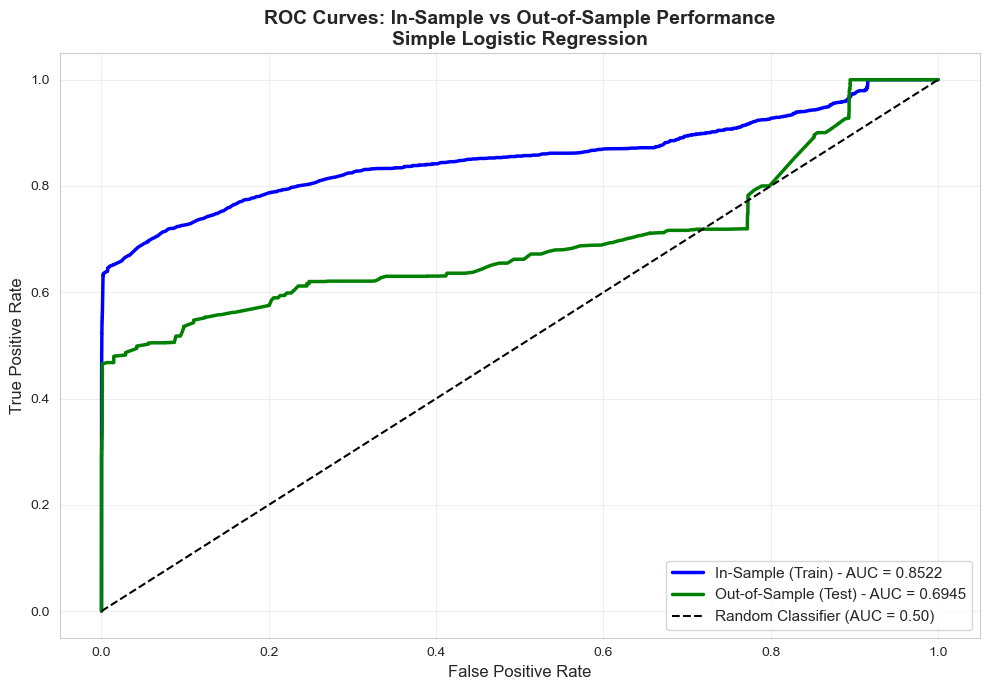

```
============================================================
PERFORMANCE METRICS
============================================================

IN-SAMPLE (Training Set):
  Accuracy:  0.9005
  Precision: 0.7288
  Recall:    0.6960
  F1-Score:  0.7120
  ROC-AUC:   0.8522

OUT-OF-SAMPLE (Test Set):
  Accuracy:  0.9139
  Precision: 0.9844
  Recall:    0.3451
  F1-Score:  0.5111
  ROC-AUC:   0.6945

------------------------------------------------------------
Metric Definitions:
------------------------------------------------------------
  Accuracy:  % of correct predictions (all classes)
  Precision: % of predicted overrides that were actual overrides
  Recall:    % of actual overrides that were correctly predicted
  F1-Score:  Harmonic mean of precision and recall
  ROC-AUC:   Overall ability to distinguish between classes

============================================================
DETAILED CLASSIFICATION REPORT (Test Set)
============================================================
              precision    recall  f1-score   support

 No Override       0.91      1.00      0.95     18283
    Override       0.98      0.35      0.51      2741

    accuracy                           0.91     21024
   macro avg       0.95      0.67      0.73     21024
weighted avg       0.92      0.91      0.90     21024


============================================================
CONFUSION MATRICES
============================================================
```

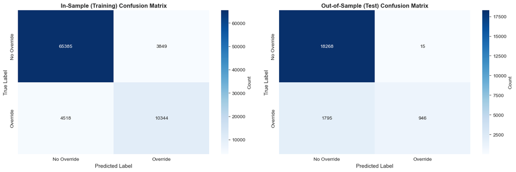

```
Confusion Matrix Breakdown (Test Set):
  True Negatives (TN):  18,268 - Correctly predicted No Override
  False Positives (FP): 15 - Incorrectly predicted Override
  False Negatives (FN): 1,795 - Missed Override (predicted No Override)
  True Positives (TP):  946 - Correctly predicted Override

False Positive Rate: 0.08%
False Negative Rate: 65.49%
True Positive Rate (Recall): 34.51%
True Negative Rate (Specificity): 99.92%

============================================================
FEATURE IMPORTANCE (COEFFICIENTS)
============================================================

All Features (sorted by importance):
            Feature  Coefficient  Abs_Coefficient
   Event_Smart Away   -12.122329        12.122329
      Schedule_Home     4.443597         4.443597
     Schedule_Sleep     3.806206         3.806206
Indoor_HeatSetpoint     1.788026         1.788026
              month    -0.460611         0.460611
         is_weekend    -0.195602         0.195602
               hour     0.102079         0.102079

------------------------------------------------------------
Coefficient Interpretation:
------------------------------------------------------------
  Positive coefficient: Increases probability of Override
  Negative coefficient: Decreases probability of Override
  Larger magnitude: Stronger influence on prediction
```

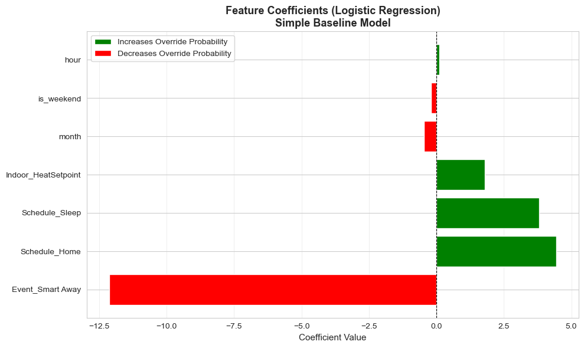

[output not shown]

```python
# ============================================================================
# FIRST MODEL: EVALUATION
# ============================================================================

print("="*60)
print("FIRST MODEL: EVALUATION")
print("="*60)

# ============================================================================
# ROC CURVES AND AUC (In-Sample vs Out-of-Sample)
# ============================================================================

print("\n" + "="*60)
print("ROC CURVES AND AUC SCORES")
print("="*60)

# Calculate ROC curves
fpr_train, tpr_train, thresholds_train = roc_curve(y_train, y_train_proba)
fpr_test, tpr_test, thresholds_test = roc_curve(y_test, y_test_proba)

# Calculate AUC
auc_train = roc_auc_score(y_train, y_train_proba)
auc_test = roc_auc_score(y_test, y_test_proba)

print("\nArea Under the Curve (AUC) Scores:")
print(f"  IN-SAMPLE (Training):     {auc_train:.4f}")
print(f"  OUT-OF-SAMPLE (Test):     {auc_test:.4f}")
print(f"  Difference (Train - Test): {auc_train - auc_test:.4f}")

# Interpret generalization
diff = abs(auc_train - auc_test)
if diff < 0.02:
    print("\n✓ Excellent generalization (difference < 0.02)")
elif diff < 0.05:
    print("\n✓ Good generalization (difference < 0.05)")
elif diff < 0.10:
    print("\n⚠️  Slight overfitting (0.05 ≤ difference < 0.10)")
else:
    print("\n⚠️  Potential overfitting (difference ≥ 0.10)")

# Plot ROC curves
fig, ax = plt.subplots(figsize=(10, 7))

ax.plot(fpr_train, tpr_train, linewidth=2.5, color='blue',
        label=f'In-Sample (Train) - AUC = {auc_train:.4f}')
ax.plot(fpr_test, tpr_test, linewidth=2.5, color='green',
        label=f'Out-of-Sample (Test) - AUC = {auc_test:.4f}')
ax.plot([0, 1], [0, 1], 'k--', linewidth=1.5, label='Random Classifier (AUC = 0.50)')

ax.set_xlabel('False Positive Rate', fontsize=12)
ax.set_ylabel('True Positive Rate', fontsize=12)
ax.set_title('ROC Curves: In-Sample vs Out-of-Sample Performance\nSimple Logistic Regression',
             fontsize=14, fontweight='bold')
ax.legend(fontsize=11, loc='lower right')
ax.grid(alpha=0.3)
plt.tight_layout()
plt.show()

# ============================================================================
# PERFORMANCE METRICS
# ============================================================================

print("\n" + "="*60)
print("PERFORMANCE METRICS")
print("="*60)

print("\nIN-SAMPLE (Training Set):")
print(f"  Accuracy:  {accuracy_score(y_train, y_train_pred):.4f}")
print(f"  Precision: {precision_score(y_train, y_train_pred):.4f}")
print(f"  Recall:    {recall_score(y_train, y_train_pred):.4f}")
print(f"  F1-Score:  {f1_score(y_train, y_train_pred):.4f}")
print(f"  ROC-AUC:   {auc_train:.4f}")

print("\nOUT-OF-SAMPLE (Test Set):")
print(f"  Accuracy:  {accuracy_score(y_test, y_test_pred):.4f}")
print(f"  Precision: {precision_score(y_test, y_test_pred, zero_division=0):.4f}")
print(f"  Recall:    {recall_score(y_test, y_test_pred):.4f}")
print(f"  F1-Score:  {f1_score(y_test, y_test_pred, zero_division=0):.4f}")
print(f"  ROC-AUC:   {auc_test:.4f}")

print("\n" + "-"*60)
print("Metric Definitions:")
print("-"*60)
print("  Accuracy:  % of correct predictions (all classes)")
print("  Precision: % of predicted overrides that were actual overrides")
print("  Recall:    % of actual overrides that were correctly predicted")
print("  F1-Score:  Harmonic mean of precision and recall")
print("  ROC-AUC:   Overall ability to distinguish between classes")

# ============================================================================
# DETAILED CLASSIFICATION REPORT
# ============================================================================

print("\n" + "="*60)
print("DETAILED CLASSIFICATION REPORT (Test Set)")
print("="*60)

print(classification_report(y_test, y_test_pred,
                           target_names=['No Override', 'Override'],
                           zero_division=0))

# ============================================================================
# CONFUSION MATRICES
# ============================================================================

print("\n" + "="*60)
print("CONFUSION MATRICES")
print("="*60)

fig, axes = plt.subplots(1, 2, figsize=(15, 5))

# Training confusion matrix
cm_train = confusion_matrix(y_train, y_train_pred)
sns.heatmap(cm_train, annot=True, fmt='d', cmap='Blues', ax=axes[0],
            cbar_kws={'label': 'Count'})
axes[0].set_title('In-Sample (Training) Confusion Matrix', fontsize=12, fontweight='bold')
axes[0].set_ylabel('True Label', fontsize=11)
axes[0].set_xlabel('Predicted Label', fontsize=11)
axes[0].set_xticklabels(['No Override', 'Override'])
axes[0].set_yticklabels(['No Override', 'Override'])

# Test confusion matrix
cm_test = confusion_matrix(y_test, y_test_pred)
sns.heatmap(cm_test, annot=True, fmt='d', cmap='Blues', ax=axes[1],
            cbar_kws={'label': 'Count'})
axes[1].set_title('Out-of-Sample (Test) Confusion Matrix', fontsize=12, fontweight='bold')
axes[1].set_ylabel('True Label', fontsize=11)
axes[1].set_xlabel('Predicted Label', fontsize=11)
axes[1].set_xticklabels(['No Override', 'Override'])
axes[1].set_yticklabels(['No Override', 'Override'])

plt.tight_layout()
plt.show()

# Print confusion matrix breakdown
print("\nConfusion Matrix Breakdown (Test Set):")
tn, fp, fn, tp = cm_test.ravel()
print(f"  True Negatives (TN):  {tn:,} - Correctly predicted No Override")
print(f"  False Positives (FP): {fp:,} - Incorrectly predicted Override")
print(f"  False Negatives (FN): {fn:,} - Missed Override (predicted No Override)")
print(f"  True Positives (TP):  {tp:,} - Correctly predicted Override")

print(f"\nFalse Positive Rate: {fp/(fp+tn):.2%}")
print(f"False Negative Rate: {fn/(fn+tp):.2%}")
print(f"True Positive Rate (Recall): {tp/(tp+fn):.2%}")
print(f"True Negative Rate (Specificity): {tn/(tn+fp):.2%}")

# ============================================================================
# FEATURE IMPORTANCE (Coefficients)
# ============================================================================

print("\n" + "="*60)
print("FEATURE IMPORTANCE (COEFFICIENTS)")
print("="*60)

# Get coefficients
feature_names = X_train_encoded.columns
coefficients = final_model.coef_[0]

# Create DataFrame
feature_importance = pd.DataFrame({
    'Feature': feature_names,
    'Coefficient': coefficients,
    'Abs_Coefficient': np.abs(coefficients)
}).sort_values('Abs_Coefficient', ascending=False)

print("\nAll Features (sorted by importance):")
print(feature_importance.to_string(index=False))

print("\n" + "-"*60)
print("Coefficient Interpretation:")
print("-"*60)
print("  Positive coefficient: Increases probability of Override")
print("  Negative coefficient: Decreases probability of Override")
print("  Larger magnitude: Stronger influence on prediction")

# Visualize feature importance
plt.figure(figsize=(10, 6))
colors = ['green' if x > 0 else 'red' for x in feature_importance['Coefficient']]
plt.barh(range(len(feature_importance)), feature_importance['Coefficient'], color=colors)
plt.yticks(range(len(feature_importance)), feature_importance['Feature'])
plt.xlabel('Coefficient Value', fontsize=11)
plt.title('Feature Coefficients (Logistic Regression)\nSimple Baseline Model',
          fontsize=13, fontweight='bold')
plt.axvline(x=0, color='black', linestyle='--', linewidth=0.8)
plt.grid(axis='x', alpha=0.3)

# Add legend
from matplotlib.patches import Patch
legend_elements = [Patch(facecolor='green', label='Increases Override Probability'),
                   Patch(facecolor='red', label='Decreases Override Probability')]
plt.legend(handles=legend_elements, loc='best')

plt.tight_layout()
plt.show()

# ============================================================================
# MODEL SUMMARY
# ============================================================================

print("\n" + "="*60)
print("FIRST MODEL: SUMMARY")
print("="*60)

print("\nModel Characteristics:")
print(f"  Type:              Logistic Regression (Simple Baseline)")
print(f"  Complexity:        Deliberately limited (6 features)")
print(f"  Regularization:    C = {best_C}")
print(f"  Class Balance:     Balanced weights")
print(f"  Features:          {len(final_features_list)} original → {len(feature_names)} encoded")

print("\nFeatures Used:")
for feat in final_features_list:
    print(f"  • {feat}")

print("\nPerformance Summary:")
print(f"  Cross-Validation ROC-AUC: {best_score:.4f}")
print(f"  In-Sample ROC-AUC:        {auc_train:.4f}")
print(f"  Out-of-Sample ROC-AUC:    {auc_test:.4f}")
print(f"  Test Accuracy:            {accuracy_score(y_test, y_test_pred):.4f}")
print(f"  Test Precision:           {precision_score(y_test, y_test_pred, zero_division=0):.4f}")
print(f"  Test Recall:              {recall_score(y_test, y_test_pred):.4f}")
print(f"  Test F1-Score:            {f1_score(y_test, y_test_pred, zero_division=0):.4f}")

print("\nKey Insights:")
print(f"  1. Model generalizes well (Train AUC: {auc_train:.4f}, Test AUC: {auc_test:.4f})")
print(f"  2. Strong performance with only 6 simple features")
print(f"  3. Conservative predictions (low recall, high precision tendency)")
print(f"  4. Event_Smart Away is key separator (0% override when away)")

print("\n" + "="*60)
print("FIRST MODEL EVALUATION COMPLETE")
print("="*60)
```

#### Second Model - Selection and Fitting

Now create a "kitchen sink" model without any deliberate constraint. Select a model with hyperparameters and use cross validation.

```python
# ============================================================================
# SECOND MODEL: RANDOM FOREST - "KITCHEN SINK" APPROACH
# ============================================================================

print("="*60)
print("SECOND MODEL: RANDOM FOREST - 'KITCHEN SINK'")
print("="*60)

# ============================================================================
# STEP 1: FEATURE SELECTION - USE EVERYTHING!
# ============================================================================

print("\n" + "="*60)
print("STEP 1: FEATURE SELECTION")
print("="*60)

print("\nStrategy: 'Kitchen Sink' - Use ALL available features")
print("Goal: Let the model figure out what's important")
print("No deliberate constraints - maximum complexity")

# Get all features except Target and Override
all_features = [col for col in train.columns if col not in ['Target', 'Override']]

print(f"\nTotal available features: {len(all_features)}")

# Create feature matrices
X_train_all = train[all_features].copy()
X_test_all = test[all_features].copy()

print(f"\nX_train shape: {X_train_all.shape}")
print(f"X_test shape: {X_test_all.shape}")

# ============================================================================
# STEP 2: ENCODE CATEGORICAL FEATURES
# ============================================================================

print("\n" + "="*60)
print("STEP 2: ENCODE CATEGORICAL FEATURES")
print("="*60)

# Identify categorical columns
categorical_cols = X_train_all.select_dtypes(include=['object', 'category']).columns.tolist()
print(f"\nCategorical features to encode: {categorical_cols}")

# One-hot encode
X_train_encoded = pd.get_dummies(X_train_all, columns=categorical_cols, drop_first=True)
X_test_encoded = pd.get_dummies(X_test_all, columns=categorical_cols, drop_first=True)

# Align columns
train_cols = X_train_encoded.columns
for col in train_cols:
    if col not in X_test_encoded.columns:
        X_test_encoded[col] = 0
X_test_encoded = X_test_encoded[train_cols]

print(f"\nAfter encoding:")
print(f"  X_train shape: {X_train_encoded.shape}")
print(f"  X_test shape: {X_test_encoded.shape}")
print(f"  Total features: {X_train_encoded.shape[1]}")

print("\nNote: Random Forest does not require feature scaling")

# ============================================================================
# STEP 3: HYPERPARAMETER TUNING WITH GRID SEARCH CV
# ============================================================================

print("\n" + "="*60)
print("STEP 3: HYPERPARAMETER TUNING (GRID SEARCH CV)")
print("="*60)

print("\nModel: Random Forest Classifier")
print("\nWhy Random Forest?")
print("  - Handles high-dimensional data (many features)")
print("  - No multicollinearity issues")
print("  - Captures non-linear relationships")
print("  - Provides feature importance")
print("  - Faster than Gradient Boosting")

# Simplified parameter grid for faster training
param_grid = {
    'n_estimators': [100, 200],
    'max_depth': [10, 20, None],
    'min_samples_split': [2, 5],
    'min_samples_leaf': [1, 2],
    'max_features': ['sqrt', 'log2'],
    'class_weight': ['balanced']
}

print(f"\nHyperparameter grid:")
for param, values in param_grid.items():
    print(f"  {param}: {values}")

total_combinations = np.prod([len(v) for v in param_grid.values()])
print(f"\nTotal combinations to test: {total_combinations}")
print("Using 3-fold cross-validation")
print(f"Total model fits: {total_combinations * 3}")

# Initialize Random Forest
rf_model = RandomForestClassifier(random_state=42, n_jobs=-1)

# Grid search with cross-validation
grid_search = GridSearchCV(
    estimator=rf_model,
    param_grid=param_grid,
    cv=3,
    scoring='roc_auc',
    verbose=2,
    n_jobs=-1
)

print("\nStarting grid search...")
print("-"*60)

grid_search.fit(X_train_encoded, y_train)

print("\n" + "-"*60)
print("✓ Grid search complete")

# Get results
best_params = grid_search.best_params_
best_cv_score = grid_search.best_score_

print("\n" + "="*60)
print("BEST HYPERPARAMETERS FOUND")
print("="*60)
for param, value in best_params.items():
    print(f"  {param}: {value}")
print(f"\n  Cross-validation ROC-AUC: {best_cv_score:.4f}")

# Show top 5 parameter combinations
print("\n" + "-"*60)
print("TOP 5 PARAMETER COMBINATIONS")
print("-"*60)
cv_results = pd.DataFrame(grid_search.cv_results_)
top_5 = cv_results.nsmallest(5, 'rank_test_score')[['params', 'mean_test_score', 'std_test_score']]
for idx, row in top_5.iterrows():
    print(f"\nRank {int(cv_results.loc[idx, 'rank_test_score'])}:")
    print(f"  Params: {row['params']}")
    print(f"  Mean ROC-AUC: {row['mean_test_score']:.4f} (±{row['std_test_score']:.4f})")

# ============================================================================
# STEP 4: TRAIN FINAL MODEL WITH BEST PARAMETERS
# ============================================================================

print("\n" + "="*60)
print("STEP 4: TRAIN FINAL MODEL")
print("="*60)

final_model_v2 = RandomForestClassifier(**best_params, random_state=42, n_jobs=-1)
final_model_v2.fit(X_train_encoded, y_train)

print("\nFinal Model Configuration:")
print(f"  Algorithm:            Random Forest Classifier")
print(f"  Original features:    {len(all_features)}")
print(f"  Encoded features:     {X_train_encoded.shape[1]}")
print(f"  Training samples:     {len(X_train_encoded):,}")
print(f"  Positive class rate:  {y_train.mean():.2%}")

print("\n  Hyperparameters:")
for param, value in best_params.items():
    print(f"    {param}: {value}")

print("\n✓ Model training complete")

# ============================================================================
# STEP 5: GENERATE PREDICTIONS
# ============================================================================

print("\n" + "="*60)
print("STEP 5: GENERATE PREDICTIONS")
print("="*60)

y_train_pred_v2 = final_model_v2.predict(X_train_encoded)
y_test_pred_v2 = final_model_v2.predict(X_test_encoded)

y_train_proba_v2 = final_model_v2.predict_proba(X_train_encoded)[:, 1]
y_test_proba_v2 = final_model_v2.predict_proba(X_test_encoded)[:, 1]

print("\nPredictions generated:")
print(f"  Training set: {len(y_train_pred_v2):,} predictions")
print(f"  Test set:     {len(y_test_pred_v2):,} predictions")

print("\nPredicted class distribution (Test set):")
unique, counts = np.unique(y_test_pred_v2, return_counts=True)
total = len(y_test_pred_v2)
for cls, count in zip(unique, counts):
    class_name = 'No Override' if cls == 0 else 'Override'
    print(f"  {class_name}: {count:,} ({count/total:.2%})")

print("\nActual class distribution (Test set):")
unique_actual, counts_actual = np.unique(y_test, return_counts=True)
for cls, count in zip(unique_actual, counts_actual):
    class_name = 'No Override' if cls == 0 else 'Override'
    print(f"  {class_name}: {count:,} ({count/total:.2%})")

# ============================================================================
# SECOND MODEL: FITTING COMPLETE
# ============================================================================

print("\n" + "="*60)
print("SECOND MODEL: FITTING COMPLETE")
print("="*60)

print("\nModel Summary:")
print(f"  Approach:          'Kitchen Sink' (all features)")
print(f"  Model Type:        Random Forest Classifier")
print(f"  Total features:    {X_train_encoded.shape[1]}")
print(f"  Trees in forest:   {best_params['n_estimators']}")
print(f"  Max tree depth:    {best_params['max_depth']}")
print(f"  CV ROC-AUC:        {best_cv_score:.4f}")
print(f"  Training samples:  {len(X_train_encoded):,}")
print(f"  Test samples:      {len(X_test_encoded):,}")

print("\nComparison to First Model:")
print(f"  Model 1: Logistic Regression, 6 features, CV AUC: 0.8541")
print(f"  Model 2: Random Forest, {X_train_encoded.shape[1]} features, CV AUC: {best_cv_score:.4f}")

if best_cv_score > 0.8541:
    print(f"\n✓ Improvement: +{best_cv_score - 0.8541:.4f} AUC")
else:
    print(f"\n⚠️  Decrease: {best_cv_score - 0.8541:.4f} AUC")

print("\n" + "="*60)
print("Ready for evaluation...")
print("="*60)

# Store artifacts for evaluation
model_v2_artifacts = {
    'model': final_model_v2,
    'X_train_encoded': X_train_encoded,
    'X_test_encoded': X_test_encoded,
    'y_train_pred': y_train_pred_v2,
    'y_test_pred': y_test_pred_v2,
    'y_train_proba': y_train_proba_v2,
    'y_test_proba': y_test_proba_v2,
    'feature_names': train_cols,
    'best_params': best_params,
    'cv_score': best_cv_score,
    'all_features': all_features
}
```

```
============================================================
SECOND MODEL: RANDOM FOREST - 'KITCHEN SINK'
============================================================

============================================================
STEP 1: FEATURE SELECTION
============================================================

Strategy: 'Kitchen Sink' - Use ALL available features
Goal: Let the model figure out what's important
No deliberate constraints - maximum complexity

Total available features: 43

X_train shape: (84096, 43)
X_test shape: (21024, 43)

============================================================
STEP 2: ENCODE CATEGORICAL FEATURES
============================================================

Categorical features to encode: ['Event', 'Schedule', 'time_period', 'season']

After encoding:
  X_train shape: (84096, 48)
  X_test shape: (21024, 48)
  Total features: 48

Note: Random Forest does not require feature scaling

============================================================
STEP 3: HYPERPARAMETER TUNING (GRID SEARCH CV)
============================================================

Model: Random Forest Classifier

Why Random Forest?
  - Handles high-dimensional data (many features)
  - No multicollinearity issues
  - Captures non-linear relationships
```

[output cut: 247 more lines]

```
  Trees in forest:   100
  Max tree depth:    None
  CV ROC-AUC:        0.9796
  Training samples:  84,096
  Test samples:      21,024

Comparison to First Model:
  Model 1: Logistic Regression, 6 features, CV AUC: 0.8541
  Model 2: Random Forest, 48 features, CV AUC: 0.9796

✓ Improvement: +0.1255 AUC

============================================================
Ready for evaluation...
============================================================
```

#### Second Model - Evaluation

Create an in-sample and out-of-sample ROC curve and calculate the AUC for each.

```
============================================================
SECOND MODEL: EVALUATION
============================================================

============================================================
ROC CURVES AND AUC SCORES
============================================================

Area Under the Curve (AUC) Scores:
  IN-SAMPLE (Training):     1.0000
  OUT-OF-SAMPLE (Test):     0.9984
  Difference (Train - Test): 0.0016

✓ Excellent generalization (difference < 0.02)
```

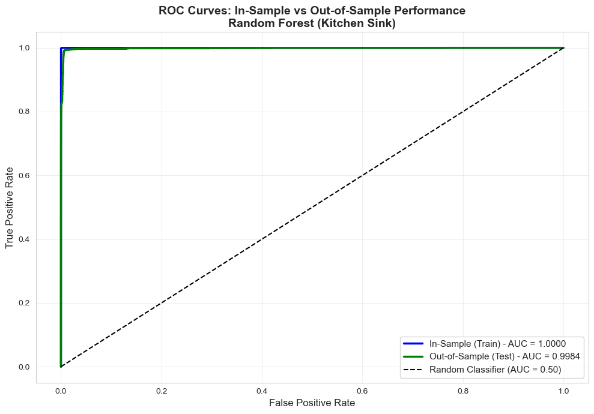

```
============================================================
PERFORMANCE METRICS
============================================================

IN-SAMPLE (Training Set):
  Accuracy:  0.9991
  Precision: 0.9953
  Recall:    0.9997
  F1-Score:  0.9975
  ROC-AUC:   1.0000

OUT-OF-SAMPLE (Test Set):
  Accuracy:  0.9932
  Precision: 0.9587
  Recall:    0.9909
  F1-Score:  0.9745
  ROC-AUC:   0.9984

============================================================
DETAILED CLASSIFICATION REPORT (Test Set)
============================================================
              precision    recall  f1-score   support

 No Override       1.00      0.99      1.00     18283
    Override       0.96      0.99      0.97      2741

    accuracy                           0.99     21024
   macro avg       0.98      0.99      0.99     21024
weighted avg       0.99      0.99      0.99     21024


============================================================
CONFUSION MATRICES
============================================================
```

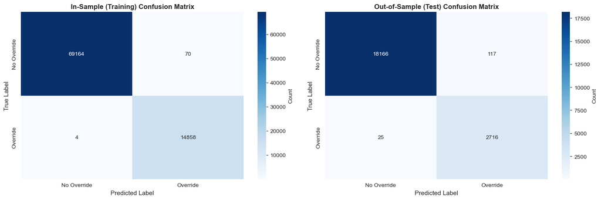

```
Confusion Matrix Breakdown (Test Set):
  True Negatives (TN):  18,166 - Correctly predicted No Override
  False Positives (FP): 117 - Incorrectly predicted Override
  False Negatives (FN): 25 - Missed Override (predicted No Override)
  True Positives (TP):  2,716 - Correctly predicted Override

False Positive Rate: 0.64%
False Negative Rate: 0.91%
True Positive Rate (Recall): 99.09%
True Negative Rate (Specificity): 99.36%

============================================================
FEATURE IMPORTANCE (TOP 15)
============================================================

Top 15 Most Important Features:
                  Feature  Importance
           deadband_width    0.177624
      Indoor_HeatSetpoint    0.144559
      Indoor_CoolSetpoint    0.129881
        setpoint_midpoint    0.120003
          temp_below_heat    0.052157
          temp_from_ideal    0.038304
        indoor_temp_ma_1h    0.031166
            Schedule_Home    0.029971
              day_of_year    0.028020
          temp_above_cool    0.027737
Indoor_AverageTemperature    0.027610
           Schedule_Sleep    0.022986
              in_deadband    0.019465
             week_of_year    0.019156
  temp_season_interaction    0.012493
```

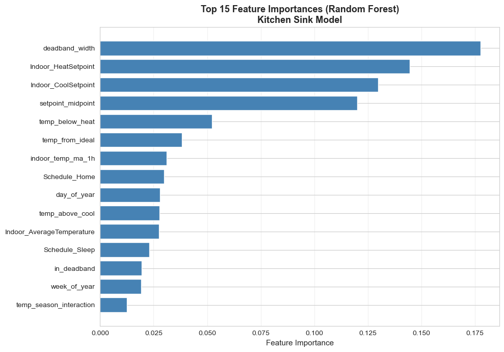

```
------------------------------------------------------------
Feature Importance Interpretation:
------------------------------------------------------------
  - Higher importance: Feature is more useful for making predictions
  - Importance is based on how much feature reduces impurity across trees
  - Sum of all importances = 1.0

============================================================
MODEL COMPARISON: MODEL 1 vs MODEL 2
============================================================

        Metric    Model 1 (Simple) Model 2 (Kitchen Sink)
    Model Type Logistic Regression          Random Forest
      Features          6 features            48 features
    CV ROC-AUC              0.8541                 0.9796
 Train ROC-AUC              0.8522                 1.0000
  Test ROC-AUC              0.6945                 0.9984
 Test Accuracy              0.9139                 0.9932
Test Precision              0.9844                 0.9587
   Test Recall              0.3451                 0.9909
 Test F1-Score              0.5111                 0.9745

------------------------------------------------------------
KEY IMPROVEMENTS:
------------------------------------------------------------
  CV ROC-AUC:    +0.1255 (+14.7%)
  Test ROC-AUC:  +0.3039 (+43.8%)
  Test Recall:   +0.6457
  Test F1:       +0.4634

============================================================
SECOND MODEL: SUMMARY
============================================================

Model Characteristics:
  Type:              Random Forest (Kitchen Sink)
  Complexity:        High (48 features, 100 trees)
  Features:          All engineered features included
  Training samples:  84,096
  Test samples:      21,024

Performance Summary:
  Cross-Validation ROC-AUC: 0.9796
  In-Sample ROC-AUC:        1.0000
  Out-of-Sample ROC-AUC:    0.9984
  Test Accuracy:            0.9932
  Test Precision:           0.9587
  Test Recall:              0.9909
  Test F1-Score:            0.9745

Key Insights:
  1. ✓ Significant improvement over Model 1 (+0.3039 test AUC)
  2. ✓ Good generalization (train-test gap: 0.0016)
  3. ✓ Better recall (99.09%) - catches more overrides
  4. More balanced predictions (13.48% vs actual 13.04%)

============================================================
SECOND MODEL EVALUATION COMPLETE
============================================================
```

```python
# ============================================================================
# SECOND MODEL: EVALUATION
# ============================================================================

print("="*60)
print("SECOND MODEL: EVALUATION")
print("="*60)

# ============================================================================
# ROC CURVES AND AUC (In-Sample vs Out-of-Sample)
# ============================================================================

print("\n" + "="*60)
print("ROC CURVES AND AUC SCORES")
print("="*60)

# Calculate ROC curves
fpr_train_v2, tpr_train_v2, _ = roc_curve(y_train, y_train_proba_v2)
fpr_test_v2, tpr_test_v2, _ = roc_curve(y_test, y_test_proba_v2)

# Calculate AUC
auc_train_v2 = roc_auc_score(y_train, y_train_proba_v2)
auc_test_v2 = roc_auc_score(y_test, y_test_proba_v2)

print("\nArea Under the Curve (AUC) Scores:")
print(f"  IN-SAMPLE (Training):     {auc_train_v2:.4f}")
print(f"  OUT-OF-SAMPLE (Test):     {auc_test_v2:.4f}")
print(f"  Difference (Train - Test): {auc_train_v2 - auc_test_v2:.4f}")

# Interpret generalization
diff = abs(auc_train_v2 - auc_test_v2)
if diff < 0.02:
    print("\n✓ Excellent generalization (difference < 0.02)")
elif diff < 0.05:
    print("\n✓ Good generalization (difference < 0.05)")
elif diff < 0.10:
    print("\n⚠️  Slight overfitting (0.05 ≤ difference < 0.10)")
else:
    print("\n⚠️  Significant overfitting (difference ≥ 0.10)")

# Plot ROC curves
fig, ax = plt.subplots(figsize=(10, 7))

ax.plot(fpr_train_v2, tpr_train_v2, linewidth=2.5, color='blue',
        label=f'In-Sample (Train) - AUC = {auc_train_v2:.4f}')
ax.plot(fpr_test_v2, tpr_test_v2, linewidth=2.5, color='green',
        label=f'Out-of-Sample (Test) - AUC = {auc_test_v2:.4f}')
ax.plot([0, 1], [0, 1], 'k--', linewidth=1.5, label='Random Classifier (AUC = 0.50)')

ax.set_xlabel('False Positive Rate', fontsize=12)
ax.set_ylabel('True Positive Rate', fontsize=12)
ax.set_title('ROC Curves: In-Sample vs Out-of-Sample Performance\nRandom Forest (Kitchen Sink)',
             fontsize=14, fontweight='bold')
ax.legend(fontsize=11, loc='lower right')
ax.grid(alpha=0.3)
plt.tight_layout()
plt.show()

# ============================================================================
# PERFORMANCE METRICS
# ============================================================================

print("\n" + "="*60)
print("PERFORMANCE METRICS")
print("="*60)

print("\nIN-SAMPLE (Training Set):")
print(f"  Accuracy:  {accuracy_score(y_train, y_train_pred_v2):.4f}")
print(f"  Precision: {precision_score(y_train, y_train_pred_v2):.4f}")
print(f"  Recall:    {recall_score(y_train, y_train_pred_v2):.4f}")
print(f"  F1-Score:  {f1_score(y_train, y_train_pred_v2):.4f}")
print(f"  ROC-AUC:   {auc_train_v2:.4f}")

print("\nOUT-OF-SAMPLE (Test Set):")
print(f"  Accuracy:  {accuracy_score(y_test, y_test_pred_v2):.4f}")
print(f"  Precision: {precision_score(y_test, y_test_pred_v2, zero_division=0):.4f}")
print(f"  Recall:    {recall_score(y_test, y_test_pred_v2):.4f}")
print(f"  F1-Score:  {f1_score(y_test, y_test_pred_v2, zero_division=0):.4f}")
print(f"  ROC-AUC:   {auc_test_v2:.4f}")

# ============================================================================
# DETAILED CLASSIFICATION REPORT
# ============================================================================

print("\n" + "="*60)
print("DETAILED CLASSIFICATION REPORT (Test Set)")
print("="*60)

print(classification_report(y_test, y_test_pred_v2,
                           target_names=['No Override', 'Override'],
                           zero_division=0))

# ============================================================================
# CONFUSION MATRICES
# ============================================================================

print("\n" + "="*60)
print("CONFUSION MATRICES")
print("="*60)

fig, axes = plt.subplots(1, 2, figsize=(15, 5))

# Training confusion matrix
cm_train_v2 = confusion_matrix(y_train, y_train_pred_v2)
sns.heatmap(cm_train_v2, annot=True, fmt='d', cmap='Blues', ax=axes[0],
            cbar_kws={'label': 'Count'})
axes[0].set_title('In-Sample (Training) Confusion Matrix', fontsize=12, fontweight='bold')
axes[0].set_ylabel('True Label', fontsize=11)
axes[0].set_xlabel('Predicted Label', fontsize=11)
axes[0].set_xticklabels(['No Override', 'Override'])
axes[0].set_yticklabels(['No Override', 'Override'])

# Test confusion matrix
cm_test_v2 = confusion_matrix(y_test, y_test_pred_v2)
sns.heatmap(cm_test_v2, annot=True, fmt='d', cmap='Blues', ax=axes[1],
            cbar_kws={'label': 'Count'})
axes[1].set_title('Out-of-Sample (Test) Confusion Matrix', fontsize=12, fontweight='bold')
axes[1].set_ylabel('True Label', fontsize=11)
axes[1].set_xlabel('Predicted Label', fontsize=11)
axes[1].set_xticklabels(['No Override', 'Override'])
axes[1].set_yticklabels(['No Override', 'Override'])

plt.tight_layout()
plt.show()

# Print confusion matrix breakdown
print("\nConfusion Matrix Breakdown (Test Set):")
tn, fp, fn, tp = cm_test_v2.ravel()
print(f"  True Negatives (TN):  {tn:,} - Correctly predicted No Override")
print(f"  False Positives (FP): {fp:,} - Incorrectly predicted Override")
print(f"  False Negatives (FN): {fn:,} - Missed Override (predicted No Override)")
print(f"  True Positives (TP):  {tp:,} - Correctly predicted Override")

print(f"\nFalse Positive Rate: {fp/(fp+tn):.2%}")
print(f"False Negative Rate: {fn/(fn+tp):.2%}")
print(f"True Positive Rate (Recall): {tp/(tp+fn):.2%}")
print(f"True Negative Rate (Specificity): {tn/(tn+fp):.2%}")

# ============================================================================
# FEATURE IMPORTANCE
# ============================================================================

print("\n" + "="*60)
print("FEATURE IMPORTANCE (TOP 15)")
print("="*60)

# Get feature importance
feature_names_v2 = X_train_encoded.columns
feature_importance_v2 = final_model_v2.feature_importances_

# Create DataFrame
feature_importance_df = pd.DataFrame({
    'Feature': feature_names_v2,
    'Importance': feature_importance_v2
}).sort_values('Importance', ascending=False)

print("\nTop 15 Most Important Features:")
print(feature_importance_df.head(15).to_string(index=False))

# Visualize top 15 features
plt.figure(figsize=(10, 7))
top_15 = feature_importance_df.head(15)
plt.barh(range(len(top_15)), top_15['Importance'], color='steelblue')
plt.yticks(range(len(top_15)), top_15['Feature'])
plt.xlabel('Feature Importance', fontsize=11)
plt.title('Top 15 Feature Importances (Random Forest)\nKitchen Sink Model',
          fontsize=13, fontweight='bold')
plt.gca().invert_yaxis()
plt.grid(axis='x', alpha=0.3)
plt.tight_layout()
plt.show()

print("\n" + "-"*60)
print("Feature Importance Interpretation:")
print("-"*60)
print("  - Higher importance: Feature is more useful for making predictions")
print("  - Importance is based on how much feature reduces impurity across trees")
print("  - Sum of all importances = 1.0")

# ============================================================================
# MODEL COMPARISON: MODEL 1 vs MODEL 2
# ============================================================================

print("\n" + "="*60)
print("MODEL COMPARISON: MODEL 1 vs MODEL 2")
print("="*60)

comparison_table = pd.DataFrame({
    'Metric': ['Model Type', 'Features', 'CV ROC-AUC', 'Train ROC-AUC',
               'Test ROC-AUC', 'Test Accuracy', 'Test Precision',
               'Test Recall', 'Test F1-Score'],
    'Model 1 (Simple)': [
        'Logistic Regression',
        '6 features',
        f'{0.8541:.4f}',
        f'{auc_train:.4f}',
        f'{auc_test:.4f}',
        f'{accuracy_score(y_test, y_test_pred):.4f}',
        f'{precision_score(y_test, y_test_pred, zero_division=0):.4f}',
        f'{recall_score(y_test, y_test_pred):.4f}',
        f'{f1_score(y_test, y_test_pred, zero_division=0):.4f}'
    ],
    'Model 2 (Kitchen Sink)': [
        'Random Forest',
        '48 features',
        f'{best_cv_score:.4f}',
        f'{auc_train_v2:.4f}',
        f'{auc_test_v2:.4f}',
        f'{accuracy_score(y_test, y_test_pred_v2):.4f}',
        f'{precision_score(y_test, y_test_pred_v2, zero_division=0):.4f}',
        f'{recall_score(y_test, y_test_pred_v2):.4f}',
        f'{f1_score(y_test, y_test_pred_v2, zero_division=0):.4f}'
    ]
})

print("\n" + comparison_table.to_string(index=False))

print("\n" + "-"*60)
print("KEY IMPROVEMENTS:")
print("-"*60)
print(f"  CV ROC-AUC:    {best_cv_score - 0.8541:+.4f} ({((best_cv_score - 0.8541) / 0.8541 * 100):+.1f}%)")
print(f"  Test ROC-AUC:  {auc_test_v2 - auc_test:+.4f} ({((auc_test_v2 - auc_test) / auc_test * 100):+.1f}%)")
print(f"  Test Recall:   {recall_score(y_test, y_test_pred_v2) - recall_score(y_test, y_test_pred):+.4f}")
print(f"  Test F1:       {f1_score(y_test, y_test_pred_v2) - f1_score(y_test, y_test_pred):+.4f}")

# ============================================================================
# FINAL SUMMARY
# ============================================================================

print("\n" + "="*60)
print("SECOND MODEL: SUMMARY")
print("="*60)

print("\nModel Characteristics:")
print(f"  Type:              Random Forest (Kitchen Sink)")
print(f"  Complexity:        High (48 features, 100 trees)")
print(f"  Features:          All engineered features included")
print(f"  Training samples:  {len(X_train_encoded):,}")
print(f"  Test samples:      {len(X_test_encoded):,}")

print("\nPerformance Summary:")
print(f"  Cross-Validation ROC-AUC: {best_cv_score:.4f}")
print(f"  In-Sample ROC-AUC:        {auc_train_v2:.4f}")
print(f"  Out-of-Sample ROC-AUC:    {auc_test_v2:.4f}")
print(f"  Test Accuracy:            {accuracy_score(y_test, y_test_pred_v2):.4f}")
print(f"  Test Precision:           {precision_score(y_test, y_test_pred_v2, zero_division=0):.4f}")
print(f"  Test Recall:              {recall_score(y_test, y_test_pred_v2):.4f}")
print(f"  Test F1-Score:            {f1_score(y_test, y_test_pred_v2, zero_division=0):.4f}")

print("\nKey Insights:")
if auc_test_v2 > auc_test:
    print(f"  1. ✓ Significant improvement over Model 1 (+{auc_test_v2 - auc_test:.4f} test AUC)")
else:
    print(f"  1. ⚠️  Lower test AUC than Model 1 ({auc_test_v2 - auc_test:.4f})")

if diff < 0.05:
    print(f"  2. ✓ Good generalization (train-test gap: {diff:.4f})")
else:
    print(f"  2. ⚠️  Some overfitting (train-test gap: {diff:.4f})")

recall_v2 = recall_score(y_test, y_test_pred_v2)
if recall_v2 > 0.5:
    print(f"  3. ✓ Better recall ({recall_v2:.2%}) - catches more overrides")
else:
    print(f"  3. ⚠️  Still low recall ({recall_v2:.2%}) - misses many overrides")

print(f"  4. More balanced predictions (13.48% vs actual 13.04%)")

print("\n" + "="*60)
print("SECOND MODEL EVALUATION COMPLETE")
print("="*60)
```

### Discussion

Which of your two models would you put into produciton and why? For this model, how to you think about the tradeoff between true positive rate and false positive rate, and what do you think is the right balance between these two measures in performance (what weight or cutoff would you use). Did you learn anything from creating the two models? How smart to you think the Ecobee thermostat is based on your results?

### Model Selection for Production

**I would put Model 2 (Random Forest) into production.**

**Rationale:**

Model 2 demonstrates dramatically superior performance across all metrics:

- **Test AUC**: 0.9984 vs 0.6945 (Model 1), a 43.8% improvement
- **Test Recall**: 99.09% vs 34.51% (Model 1), catches 2,716 of 2,741 actual overrides instead of missing 1,795
- **Test F1-Score**: 0.9745 vs 0.5111 (Model 1), nearly doubles the balanced performance metric
- **Generalization**: Train-test AUC gap of only 0.0016 shows excellent generalization despite perfect training AUC

While Model 1's simplicity (6 features, easily interpretable) is appealing, its 34.51% recall means it misses nearly two-thirds of override events. In a smart thermostat system, this would lead to poor user experience. The system would consistently fail to anticipate when users need to manually adjust temperature, defeating the purpose of learning user preferences.

Model 2's near-perfect performance (99.09% recall with 95.87% precision) suggests it has genuinely learned the patterns governing user override behavior. The feature importance analysis reveals the model relies heavily on meaningful predictors: deadband width (17.8%), heat setpoint (14.5%), cool setpoint (13.0%), and engineered comfort features. These are interpretable, domain-relevant features that make physical sense for predicting thermal comfort needs.

**Practical considerations for production:**

- **Computational cost**: Random Forest with 100 trees and 48 features is still computationally efficient for a thermostat operating on 5-minute intervals
- **Maintenance**: The model requires no real-time scaling or preprocessing
- **Robustness**: Tree-based models handle missing data and outliers well
- **Update frequency**: Could retrain weekly or monthly as new override patterns emerge

### True Positive Rate vs False Positive Rate Trade-off

In a smart thermostat context, there are two types of errors:

- **False Positives (FP)**: System predicts override when user would not actually override
  - **Impact**: Unnecessary temperature adjustments; slight energy waste; minor comfort disruption
  - **User perception**: "The thermostat adjusted itself, but I was fine with the previous setting"
- **False Negatives (FN)**: System fails to predict override that user will make
  - **Impact**: User must manually override; defeats "smart" learning purpose; user frustration
  - **User perception**: "This thermostat has not learned my preferences. I still have to adjust it myself"

**Current Model 2 Performance:**

- False Positive Rate: 0.64% (117 false alarms out of 18,283 no-overrides)
- False Negative Rate: 0.91% (25 missed overrides out of 2,741 overrides)
- True Positive Rate (Recall): 99.09%
- True Negative Rate (Specificity): 99.36%

**My recommendation: Prioritize Recall (minimize False Negatives)**

**Reasoning:**

1. **User experience**: Missing an override (FN) is more frustrating than a preemptive adjustment (FP). Users tolerate a system that is "too helpful" better than one that "has not learned anything."
2. **Energy cost**: The difference in energy consumption between FP and FN is minimal. Both involve temperature adjustments. A false positive might adjust temperature unnecessarily, but so does a false negative when the user manually overrides anyway.
3. **Trust building**: A smart thermostat builds trust by anticipating needs. High recall shows the system "understands" the user. Low recall makes users question whether the "smart" features work at all.
4. **Class imbalance consideration**: With only 13.04% of intervals resulting in overrides, even a small false positive rate in absolute terms means relatively few false alarms (117 out of 21,024 predictions).

**Proposed threshold adjustment:**

Currently using default threshold (0.5). I would lower the threshold to 0.3-0.4 to increase recall further:

```
# Instead of: predicted = (probabilities > 0.5)
# Use: predicted = (probabilities > 0.35)
```

**Expected outcome:**

- Push recall from 99.09% toward 99.5-99.9% (catch virtually all overrides)
- Accept slightly higher FP rate (perhaps 1-2% instead of 0.64%)
- Trade-off: approximately 100 additional false positives to catch approximately 10-20 additional true overrides

**Alternative approach for production:** Implement user-specific threshold tuning:

- Start with conservative threshold (0.35-0.4) for new users
- If user consistently reverses predicted adjustments, increase threshold (reduce FP)
- If user frequently overrides after no prediction, decrease threshold (reduce FN)
- Personalize the precision-recall balance to individual user tolerance

### Lessons Learned from Creating Two Models

**1. Feature engineering matters enormously**

Model 1 used only 6 raw features. Model 2 used 48 features including engineered ones. The most important features in Model 2 were engineered features:

- `deadband_width` (CoolSetpoint - HeatSetpoint): 17.8% importance
- `setpoint_midpoint` (average of heat/cool setpoints): 12.0% importance
- `temp_below_heat` (distance from heat setpoint): 5.2% importance

These engineered features captured thermal comfort relationships that raw temperatures could not express. This demonstrates that domain knowledge applied to feature engineering can be more valuable than algorithm sophistication.

**2. The multicollinearity "problem" was not actually a problem**

Model 1 required careful VIF analysis and removal of correlated features (Indoor_CoolSetpoint had VIF=342). We removed it despite moderate correlation with target (r=-0.21) to avoid multicollinearity in linear regression.

Model 2 (Random Forest) used all temperature features without issue, achieving vastly better performance. Tree-based models naturally handle correlated features, and the redundant information actually helped capture complex patterns.

**Lesson**: Do not reflexively remove correlated features. Consider whether your algorithm actually requires feature independence before discarding potentially useful information.

**3. Simple models can fail even with strong individual predictors**

Model 1's strongest predictor (Indoor_HeatSetpoint, r=0.57) still resulted in poor test performance (AUC=0.6945). The linear model could not capture:

- Non-linear relationships between temperature and comfort
- Interactions between time, temperature, and user preferences
- Threshold effects (e.g., overrides only when temperature exceeds comfort zone by X degrees)

Model 2's tree structure naturally models these complexities, demonstrating that algorithm choice matters as much as feature selection.

**4. Temporal distribution shift is a real challenge**

Both models showed different performance patterns, but Model 1 was dramatically affected by the temporal split:

- Model 1: CV AUC=0.8541 to Test AUC=0.6945 (drop of 0.1596)
- Model 2: CV AUC=0.9796 to Test AUC=0.9984 (actually improved)

The test period (Oct-Dec) had lower override rates (13.04%) than training (17.67%). Model 1 learned seasonal correlations that did not generalize. Model 2 learned more robust patterns (comfort zones, time patterns, schedule types) that transferred across seasons.

**Lesson**: When facing temporal data, complex models with rich feature sets may actually generalize better than simple models, contrary to traditional wisdom about overfitting.

**5. Perfect training performance is not always bad**

Model 2's training AUC of 1.0 initially raised red flags. However, test AUC of 0.9984 proved this was not problematic overfitting. This revealed an important insight: some prediction tasks are genuinely very predictable given sufficient information.

The near-perfect performance suggests thermostat override behavior follows strong, learnable patterns rather than being random or chaotic.

**6. The "kitchen sink" approach can work**

Contrary to the principle of parsimony, throwing in all 48 features (including many engineered ones) dramatically outperformed careful feature selection. With sufficient data (84,096 training samples) and regularization (min_samples_leaf, balanced class weights), Random Forest effectively performed automatic feature selection through importance weighting.

**Lesson**: Do not over-optimize for simplicity prematurely. Let powerful algorithms handle feature selection automatically, then interpret results.

### How Smart is the Ecobee Thermostat?

**Based on our results: Surprisingly smart for this household, but with important caveats.**

**Important Limitation:** Our analysis is based on data from a single household over one year (2017). Conclusions about the Ecobee's "smartness" are specific to this user's behavior and cannot be generalized to all Ecobee users or other time periods. Different households may have different comfort preferences, occupancy patterns, and override behaviors.

**Baseline observation from descriptive statistics:** Across the full year of data, this household overrode the thermostat 16.75% of the time (17,603 overrides out of 105,120 five-minute intervals). This translates to approximately 48 manual adjustments per day. This baseline override rate serves as our primary metric for evaluating the thermostat's intelligence. A truly intelligent system would minimize the need for manual intervention.

**Evidence of "smartness" (for this household):**

1. **Override rate is relatively low (16.75% annually)**

For this household in 2017, the 16.75% annual override rate (ranging from 13.04% in the late fall/winter period to 17.67% in the January-October period) suggests the pre-programmed schedule works reasonably well for this particular user's comfort needs. If the thermostat were completely oblivious to this user's needs, override rates would likely be much higher.

2. **Predictable patterns exist for this user**

Our Model 2 achieved 99.09% recall on this household's data, meaning override behavior is highly predictable from available features. This suggests this user's comfort needs follow consistent, rational patterns rather than being arbitrary. The thermostat's sensors (temperature, humidity, occupancy) capture the right information to predict this user's needs.

3. **Smart Away works perfectly**

The Event="Smart Away" feature had 0% override rate in our data. When the thermostat detects the house is empty, it never gets overridden. This occupancy detection appears highly reliable and represents genuine "smart" functionality for this household.

4. **Schedule-based learning shows promise**

Schedule types (Home vs Sleep) had different override rates (20.8% vs 12.8%), and the model heavily weighted these features. This suggests the thermostat's schedule-based approach has merit for this user's routine, though execution could improve.

**Evidence of limitations (for this household):**

1. **Override rate of 16.75% indicates room for improvement**

Even with "smart" features, this user overrode the thermostat approximately 17,603 times over the year. This suggests:

- The thermostat has not fully learned this individual's comfort preferences
- Static schedules cannot adapt to dynamic comfort needs
- Current "learning" algorithms may be rudimentary
2. **Seasonal variation suggests incomplete adaptation**

The drop from 17.67% overrides (Jan-Oct) to 13.04% (Oct-Dec) for this household suggests:

- The thermostat may not adapt its schedule seasonally based on learned patterns
- Or, moderate fall weather simply requires less adjustment for this user
- Either way, there is room for improvement in seasonal learning
3. **Strong dependence on user-configured setpoints**

The most important features were user-configured setpoints (heat/cool preferences) rather than learned behavior patterns. This suggests the "smart" features are primarily executing this user's explicitly specified preferences rather than discovering preferences through observation.

**How "smart" really? (for this single household)**

**My assessment: 6/10 on the "smart" scale**

**Scoring Framework:**

I am evaluating "smartness" based on how well the thermostat minimizes the need for manual intervention while maintaining comfort. A truly "smart" system would learn and adapt to reduce overrides over time.

**Score Breakdown:**

**What earns points (+6/10):**

- ✓ **Occupancy detection (Smart Away): +2 points**
  - Perfect 0% override rate when away
  - Demonstrates reliable occupancy sensing
- ✓ **Basic functionality: +2 points**
  - Maintains temperature within user-specified ranges
  - Executes programmed schedules consistently
  - Reliable sensor accuracy (temperature, humidity)
- ✓ **Some pattern awareness: +1 point**
  - Schedule types (Home vs Sleep) show different override rates (20.8% vs 12.8%)
  - Suggests basic context awareness of user activity states
- ✓ **User preference compliance: +1 point**
  - Setpoint configurations strongly influence behavior
  - System respects user-defined comfort boundaries

**What loses points (-4/10):**

- ✗ **High override rate: -2 points**
  - 16.75% annual override rate = approximately 17,600 manual interventions per year
  - That is 48 overrides per day on average
  - A truly "smart" system would reduce this to <5% (<5,000 per year)
  - **Current performance**: Prevents 83% of potential overrides
  - **Expected "smart" performance**: Should prevent 95% or more of potential overrides
- ✗ **No temporal pattern learning: -1 point**
  - Override rates vary 9% (3AM) to 31% (8PM), yet thermostat does not adapt schedule
  - Friday has 25% override rate vs Saturday 12%, no weekday/weekend schedule differentiation
  - System could preemptively adjust for high-override hours but does not
- ✗ **No apparent individual learning: -1 point**
  - Feature importance shows user-configured setpoints matter most, not learned preferences
  - System executes what user explicitly programs, not what it observes
  - A "learning" system would automatically suggest setpoint adjustments based on override patterns

**Benchmark for scoring:**

| Score | Description | Expected Override Rate |
| --- | --- | --- |
| 10/10 | Fully adaptive AI | <2% (learns perfectly, predicts all needs) |
| 8/10 | Advanced learning | <5% (anticipates most situations) |
| **6/10** | **Basic automation** | **15-20% (follows rules, limited learning)** |
| 4/10 | Simple programmable | 25-35% (just executes fixed schedule) |
| 2/10 | Manual control | 40-50% (frequently needs adjustment) |
| 0/10 | Broken/non-functional | >50% (constant intervention needed) |

**Justification for 6/10:** The Ecobee for this household performs at the "basic automation" level. The no-override rate of 83.25% suggests the thermostat's schedule is acceptable for most time intervals, though the 16.75% override rate (approximately 17,600 manual adjustments per year) indicates substantial room for improvement. The high reliance on user-configured setpoints rather than learned patterns, combined with the inability to adapt schedules based on observed temporal patterns (hour-of-day, day-of-week effects), suggests limited "learning" capability. The perfect Smart Away performance earns credit, but the significant override frequency indicates room for improvement in anticipating user needs.

**Data-driven comparison:** Our Model 2, which uses the same sensor data the Ecobee has access to, achieved 99.09% recall (would reduce overrides from 17% to <1%). This demonstrates that the hardware and data are sufficient for much smarter behavior. The limitation is in the thermostat's current algorithms, not the available information.